# Modeling Guilty Minds, Study 2: NLP, Random Forest & SHAP Analysis

## The Study 1 machine learning analyses, repeated on Study 2 (not registered)

### David George Kamper, Andrew Bistras, Jaime Castrellon

This notebook repeats on Study 2 the analyses of the Study 1 notebook (`MPC_NLP_SHAP_Analysis_2.0.ipynb`), with the same code and the same settings. It fits random forest classifiers that predict the category each participant chose from the six vignette features, with and without the belief rating; computes SHAP feature importance, overall and for each category; embeds the 64 vignettes with BGE-large (primary) and MiniLM (a check); projects them with UMAP; runs the representational similarity analysis (RSA); and analyzes the free-text justifications with embeddings, BERTopic topics and a classifier that predicts the choice from the justification. The seed, models, hyperparameters, cross-validation folds and figure style are the ones Study 1 used.

None of these analyses is in the Study 2 preregistration. They are exploratory, and the manuscript should describe them as unregistered analyses that repeat the Study 1 machine learning analyses. The registered analyses are in `MPC_Study2_Analysis.Rmd`; this notebook runs after it and changes nothing in it.

The same code also runs on the Study 1 data in the folder, and the first thing to check is that it reproduces the published Study 1 numbers. When it does, any difference between the studies comes from the data and not from the code. Two questions matter most for the revision: whether the Study 1 SHAP pattern for Knowledge, in which the contents of the package mattered more than the payment, appears again in Study 2, and whether the RSA result replicates.

Several additions go beyond the Study 1 notebook, and each is labeled where it appears. The most important uses Study 2's three probe questions, which define a second category for every case: Knowledge if the participant answered that he knew, or was practically certain, that illicit material was in the package; otherwise Recklessness if he was aware of a substantial risk of it; otherwise Negligence if he should have been aware of that risk; otherwise Blamelessness. The random forest, SHAP, RSA, topic and text analyses are repeated with this probe-defined category as the outcome. The other additions check the Study 1 results themselves: a participant bootstrap shows how stable the SHAP ranking of the features is, a table of plain percentages gives the direction that SHAP importances leave out, a permutation p value for the RSA treats the 64 vignettes rather than the 2,016 vignette pairs as the units, the vignette means of the two studies are correlated directly, the text classifier is rerun with balanced class weights, and the topics are crossed with the registered justification codes. A closing table sets each published Study 1 number beside its rerun and its Study 2 counterparts.

In both studies the slider asked what the defendant believed was the chance that illicit material was in the package, so this notebook calls it the belief rating; the Study 1 notebook called it the risk slider. The category chosen from the four Model Penal Code options is called the choice. Figures are saved as PDFs without titles in `output/nlp/figures`, with the prefix `fig_s2_` (grayscale, except the SHAP beeswarm and dependence plots, which keep SHAP's colors as in Study 1), and tables are saved as CSV files in `output/nlp` for the combined report. The notebook never prints an individual justification.

## 0. Environment Setup

```python
# ── Where the study2_analysis folder is ──
FOLDER_IN_DRIVE = "/content/drive/MyDrive/DGK Lab/Reasoning Lab/DGK Lab - Mens Rea /Analysis/Mens Rea/study2_analysis"   # Colab: the folder's path inside your Google Drive
LOCAL_FOLDER = None                          # local: None means the folder Jupyter was started in

import os, sys, subprocess, importlib.metadata
os.environ["HF_HUB_DISABLE_PROGRESS_BARS"] = "1"   # keeps download bars (and their widgets) out of the output
os.environ["TOKENIZERS_PARALLELISM"] = "false"

IN_COLAB = "google.colab" in sys.modules
if IN_COLAB:
    from google.colab import drive
    drive.mount("/content/drive")
    ROOT = os.path.join("/content/drive", FOLDER_IN_DRIVE)
else:
    ROOT = LOCAL_FOLDER or os.getcwd()
os.chdir(ROOT)
needed = ["data/processed/study2_trials.csv", "data/study1_trials.csv", "materials/mensReaVignettes_binary.json"]
missing = [f for f in needed if not os.path.exists(f)]
assert not missing, f"Not found in {ROOT}: {missing}. Is this the study2_analysis folder?"
print("Working in", ROOT, "(Colab)" if IN_COLAB else "(local)")
```

```
Working in /content/drive/MyDrive/DGK Lab/Reasoning Lab/DGK Lab - Mens Rea /Analysis/Mens Rea/study2_analysis (Colab)
```

```python
# ── Install the package versions the Study 1 notebook ran with ──
# These are the versions printed in the Study 1 notebook's session information, so that both studies
# run on the same code. hdbscan (which BERTopic uses) was not listed there, so its version is fixed here.
PINS = {"scikit-learn": "1.6.1", "shap": "0.51.0", "sentence-transformers": "5.3.0",
        "umap-learn": "0.5.11", "bertopic": "0.17.4", "hdbscan": "0.8.44"}

def installed(package):
    try:
        return importlib.metadata.version(package)
    except importlib.metadata.PackageNotFoundError:
        return None

to_install = [f"{p}=={v}" for p, v in PINS.items() if installed(p) != v]
if to_install:
    print("Installing:", " ".join(to_install))
    subprocess.run([sys.executable, "-m", "pip", "install", "-q", *to_install], check=True)
print("Pinned packages:", ", ".join(f"{p} {installed(p)}" for p in PINS))
```

```
Installing: shap==0.51.0 sentence-transformers==5.3.0 umap-learn==0.5.11 bertopic==0.17.4
Pinned packages: scikit-learn 1.6.1, shap 0.51.0, sentence-transformers 5.3.0, umap-learn 0.5.11, bertopic 0.17.4, hdbscan 0.8.44
```

```python
import json, glob, time, platform, warnings
import numpy as np
import pandas as pd
import matplotlib.pyplot as plt
from matplotlib.lines import Line2D
import seaborn as sns
from scipy import stats
from scipy.spatial.distance import pdist, squareform

import sklearn
from sklearn.ensemble import RandomForestClassifier
from sklearn.linear_model import LogisticRegression
from sklearn.model_selection import StratifiedKFold, cross_val_predict
from sklearn.metrics import (classification_report, confusion_matrix,
                             accuracy_score, cohen_kappa_score)

import torch, transformers
import shap
import sentence_transformers
from sentence_transformers import SentenceTransformer
import umap

# BERTopic import: as in the Study 1 notebook, the topic models are skipped if it fails on a runtime.
try:
    from bertopic import BERTopic
    BERTOPIC_AVAILABLE = True
except ImportError as e:
    BERTOPIC_AVAILABLE = False
    print("BERTopic not available; skipping topic modeling cells.", e)

transformers.utils.logging.disable_progress_bar()
warnings.filterwarnings('ignore', category=FutureWarning)
warnings.filterwarnings('ignore', category=UserWarning)

# A package already loaded in this session at another version would make the pins meaningless.
loaded = {"scikit-learn": sklearn.__version__, "shap": shap.__version__,
          "sentence-transformers": sentence_transformers.__version__}
wrong = {p: v for p, v in loaded.items() if v != PINS[p]}
wrong.update({p: installed(p) for p in PINS if installed(p) != PINS[p]})
assert not wrong, (f"These versions differ from the pins: {wrong}. Restart the session "
                   "(Colab: Runtime, then Restart session) and run the notebook again from the top.")

# Reproducibility: the Study 1 seed.
SEED = 2026
np.random.seed(SEED)

# The two embedding models, pinned to the repository versions that were current when the Study 1
# notebook ran. The only later change to either repository added metadata, so the weights are the
# ones Study 1 used.
BGE_MODEL, BGE_REVISION = "BAAI/bge-large-en-v1.5", "d4aa6901d3a41ba39fb536a557fa166f842b0e09"
MINI_MODEL, MINI_REVISION = "sentence-transformers/all-MiniLM-L6-v2", "c9745ed1d9f207416be6d2e6f8de32d1f16199bf"

SAMPLE = "full"   # "full": everyone who passed the registered exclusions (the primary sample); "first_200": the robustness sample
N_BOOT = 200      # participant bootstrap resamples for the SHAP stability check (Section 6)
N_PERM = 10000    # vignette permutations for the RSA permutation test (Section 8)

OUT_DIR = "output/nlp" if SAMPLE == "full" else f"output/nlp_{SAMPLE}"
FIG_DIR = os.path.join(OUT_DIR, "figures")
os.makedirs(FIG_DIR, exist_ok=True)

# Publication figure defaults (the Study 1 settings): grayscale, clean, no titles (titles go in captions).
plt.rcParams.update({
    'figure.dpi': 150,
    'savefig.dpi': 300,
    'font.size': 11,
    'axes.titlesize': 12,
    'axes.labelsize': 11,
    'xtick.labelsize': 10,
    'ytick.labelsize': 10,
    'legend.fontsize': 10,
    'figure.facecolor': 'white',
    'axes.facecolor': 'white',
    'axes.edgecolor': 'black',
    'axes.linewidth': 0.8,
})

def save_fig(name):
    # Save the current figure as a PDF in the figures folder, then show it.
    path = os.path.join(FIG_DIR, name)
    plt.savefig(path, bbox_inches='tight')
    plt.show()
    print("Saved:", path)

def save_table(df, name):
    path = os.path.join(OUT_DIR, name)
    df.to_csv(path, index=False)
    print("Saved:", path)

def fmt_p(p):
    # p values for printed tables; the saved tables keep the exact values.
    return "< .0001" if p < 0.0001 else f"{p:.4f}"

print(f"Python {platform.python_version()} | scikit-learn {sklearn.__version__} | shap {shap.__version__} | "
      f"sentence-transformers {sentence_transformers.__version__} | umap-learn {installed('umap-learn')} | "
      f"bertopic {installed('bertopic')} | hdbscan {installed('hdbscan')} | torch {torch.__version__}")
print(f"GPU available: {torch.cuda.is_available()} | sample: {SAMPLE} | outputs in {OUT_DIR}")
print("All imports loaded successfully.")
```

```
Python 3.13.15 | scikit-learn 1.6.1 | shap 0.51.0 | sentence-transformers 5.3.0 | umap-learn 0.5.11 | bertopic 0.17.4 | hdbscan 0.8.44 | torch 2.11.0+cu130
GPU available: True | sample: full | outputs in output/nlp
All imports loaded successfully.
```

## 1. Data Loading & Preprocessing

Study 2 comes from `data/processed/study2_trials.csv`, written by `01b_assemble_tables.R`: one row per case, five cases per person, for everyone in the full sample (all completers who passed the registered exclusions), which is the primary sample of the registered analysis. Setting `SAMPLE = "first_200"` in the setup cell restricts the analyses to the first 200 completions and writes the outputs to a separate folder. The six features are coded 1 for the level the Study 1 notebook treated as more incriminating: a biker rather than an uncle, a duffel bag rather than a gift-wrapped package, being told what was inside rather than asking, $1,000 rather than no payment, Mexico rather than Canada, and fentanyl rather than drugs for a rare disease.

Study 1 comes from `data/study1_trials.csv`, the file the Study 1 notebook read. Its exclusion (participants with exactly five trials) and its feature coding are applied exactly as in that notebook, and its row order is kept, so its cross-validation folds are the same ones.

In both studies the culpability score runs from 1 (Blamelessness) to 4 (Knowledge), and every case's six features are checked against the text of the vignette it showed. The probe-defined category (Study 2 only) follows the registered analysis: Knowledge if the answer to the KNEW question was Yes; otherwise Recklessness if the answer to AWARE was Yes; otherwise Negligence if the answer to SHOULD was Yes; otherwise Blamelessness.

```python
# ── Categories and features (the Study 1 definitions) ──
JUDGMENT_ORDER = ['Blamelessness', 'Negligence', 'Recklessness', 'Knowledge']
culp_map = {'Blamelessness': 1, 'Negligence': 2, 'Recklessness': 3, 'Knowledge': 4}

FEATURES = ['source', 'package', 'inquiry', 'payment', 'location', 'contents']
FEATURE_COLS_NO_SLIDER = [f + '_bin' for f in FEATURES]
FEATURE_COLS = ['belief'] + FEATURE_COLS_NO_SLIDER          # the belief rating first, as in the Study 1 notebook
FEATURE_LABELS_NO_SLIDER = ['Source (biker)', 'Package (duffel)', 'Inquiry (told)',
                            'Payment ($1000)', 'Location (Mexico)', 'Contents (fentanyl)']
FEATURE_LABELS = ['Belief rating'] + FEATURE_LABELS_NO_SLIDER

# ── Study 2 ──
s2 = pd.read_csv("data/processed/study2_trials.csv", dtype={"vignette_id": str, "participant": str})
if SAMPLE == "first_200":
    s2 = s2[s2["first_200"].astype(str).str.upper() == "TRUE"]
d2 = pd.DataFrame({
    "pid": s2["participant"].values,
    "position": s2["vignette_position"].astype(int).values,
    "vignette_id": s2["vignette_id"].str.zfill(6).values,
    "judgment": s2["choice"].values,
    "belief": s2["slider"].astype(float).values,
    "justification": s2["justification"].values,
    "knew": s2["knew"].values, "aware": s2["aware"].values, "should": s2["should"].values})
for f in FEATURES:
    d2[f + "_bin"] = s2[f].astype(int).values
d2["probe_judgment"] = np.select(
    [d2["knew"].values == "Yes", d2["aware"].values == "Yes", d2["should"].values == "Yes"],
    ["Knowledge", "Recklessness", "Negligence"], default="Blamelessness")

# ── Study 1, with the Study 1 notebook's exclusion and coding ──
raw1 = pd.read_csv("data/study1_trials.csv", dtype={"vignette_id": str})
completions = raw1.groupby("session_id").size()
r1 = raw1[raw1["session_id"].isin(completions.index[completions == 5])]
d1 = pd.DataFrame({
    "pid": r1["session_id"].values,
    "position": r1["vignette_position"].astype(int).values,
    "vignette_id": r1["vignette_id"].astype(str).str.zfill(6).values,
    "judgment": r1["judgment"].values,
    "belief": r1["slider_value"].astype(float).values,
    "justification": r1["justification"].values})
d1["source_bin"]   = (r1["source"].values == "biker").astype(int)
d1["package_bin"]  = (r1["package"].values == "duffel_bag").astype(int)
d1["inquiry_bin"]  = (r1["inquiry"].values == "source_tells").astype(int)
d1["payment_bin"]  = (r1["payment"].str.replace(",", "").str.strip().values == "$1000").astype(int)
d1["location_bin"] = (r1["location"].values == "Mexico").astype(int)
d1["contents_bin"] = (r1["contents"].values == "fentanyl").astype(int)

for d in (d1, d2):
    d["culpability"] = d["judgment"].map(culp_map)
d2["probe_culpability"] = d2["probe_judgment"].map(culp_map)

# ── Check every case's features against the text of its vignette ──
with open("materials/mensReaVignettes_binary.json", encoding="utf-8") as fh:
    vignette_json = json.load(fh)
templates = {v["id"].zfill(6): v["vignette"] for v in vignette_json}

def text_features(t):
    return [int("biker" in t), int("duffel" in t), int(" tells " in t),
            int("$1000" in t), int("[MEXICO_LOC]" in t), int("fentanyl" in t)]

STUDIES = {"Study 1": d1, "Study 2": d2}
for name, d in STUDIES.items():
    from_text = np.array([text_features(templates[v]) for v in d["vignette_id"]])
    assert (from_text == d[FEATURE_COLS_NO_SLIDER].values).all(), f"{name}: features disagree with the vignette text"
    assert d["culpability"].notna().all() and d.groupby("pid").size().eq(5).all()
    print(f"{name}: {len(d)} trials from {d['pid'].nunique()} participants; "
          "every case's six features match its vignette text.")

print()
print("Judgment distribution:")
print(pd.DataFrame({"Study 1 choice": d1["judgment"].value_counts(),
                    "Study 2 choice": d2["judgment"].value_counts(),
                    "Study 2 probe-defined": d2["probe_judgment"].value_counts()}).reindex(JUDGMENT_ORDER))
```

```
Study 1: 1060 trials from 212 participants; every case's six features match its vignette text.
Study 2: 1310 trials from 262 participants; every case's six features match its vignette text.

Judgment distribution:
               Study 1 choice  Study 2 choice  Study 2 probe-defined
Blamelessness             177             158                    330
Negligence                452             643                    368
Recklessness              286             376                    287
Knowledge                 145             133                    325
```

## 2. Vignette Text Reconstruction

As in the Study 1 notebook, each vignette's text comes from the experiment's JSON file (`mensReaVignettes_binary.json`), with the three placeholders replaced by fixed constants ("John", "Winnipeg, Canada" and "Nogales, Mexico"), because the name and town were randomized on each trial and are not part of the manipulation. Embedding distances therefore reflect only the six manipulated features.

Both studies used the same 64 vignettes from the same file, so the vignette texts and their embeddings are identical for the two studies and only the judgments differ. The vignette ID (six digits, read left to right as source, package, inquiry, payment, location and contents) serves as the key for each vignette; the Study 1 notebook used a string of the six feature levels, which identifies the same 64 vignettes.

```python
# ── Build vignette texts from the ground-truth JSON ──
def fill_template(template):
    # Replace the JSON placeholders with fixed constants (as in the Study 1 notebook).
    return (template
            .replace('[NAME]', 'John')
            .replace('[CANADA_LOC]', 'Winnipeg, Canada')
            .replace('[MEXICO_LOC]', 'Nogales, Mexico'))

json_text_lookup = {vid: fill_template(t) for vid, t in templates.items()}
VIGNETTE_IDS = sorted(json_text_lookup)          # the 64 vignettes, in ID order
for name, d in STUDIES.items():
    d["vignette_text"] = d["vignette_id"].map(json_text_lookup)
    assert d["vignette_text"].notna().all()
    print(f"{name}: all {len(d)} trials matched to their vignette text; {d['vignette_id'].nunique()} different vignettes shown.")
print(f"JSON lookup built: {len(VIGNETTE_IDS)} vignettes")
```

```
Study 1: all 1060 trials matched to their vignette text; 64 different vignettes shown.
Study 2: all 1310 trials matched to their vignette text; 64 different vignettes shown.
JSON lookup built: 64 vignettes
```

## 3. Sentence-Transformer Embeddings

We embed the unique vignette texts using two models, as in Study 1. The primary model is `BAAI/bge-large-en-v1.5` (1024 dimensions), which pools through the CLS token and was trained contrastively with hard negatives, so it is built to tell similar texts apart; this matters because the vignettes share most of their wording. The check is `all-MiniLM-L6-v2` (384 dimensions, mean pooling), a widely used lightweight model that shows whether the RSA depends on the choice of embedding model. Both are pinned to the repository versions the Study 1 notebook used. The justification embeddings are computed in Section 9.

```python
# ── Load embedding models ──
st_model_bge = SentenceTransformer(BGE_MODEL, revision=BGE_REVISION)
st_model_mini = SentenceTransformer(MINI_MODEL, revision=MINI_REVISION)
print("Embedding device:", st_model_bge.device)

# ── Embed the 64 vignette texts with both models ──
unique_texts = [json_text_lookup[v] for v in VIGNETTE_IDS]
vignette_embeddings_bge = st_model_bge.encode(unique_texts, batch_size=32, normalize_embeddings=True)
vignette_embeddings_mini = st_model_mini.encode(unique_texts, batch_size=32, normalize_embeddings=True)
key_to_embedding_bge = dict(zip(VIGNETTE_IDS, vignette_embeddings_bge))
key_to_embedding_mini = dict(zip(VIGNETTE_IDS, vignette_embeddings_mini))

print(f"BGE embedding shape: {vignette_embeddings_bge.shape}")
print(f"MiniLM embedding shape: {vignette_embeddings_mini.shape}")
```

```
Embedding device: cuda:0
BGE embedding shape: (64, 1024)
MiniLM embedding shape: (64, 384)
```

## 4. UMAP Dimensionality Reduction

As in Study 1, UMAP projects the 64 vignette embeddings (BGE-large) into two dimensions, with the Study 1 settings, and the projection is colored by the vignettes' mean culpability, here Study 2's, and by payment. UMAP projections are sensitive to their settings and can change across runs and package versions, so these plots are exploratory and suited to supplementary material rather than to primary figures. Because the texts and the model are the ones Study 1 used, the projection does not depend on the study. The Study 1 figure that colors it by each of the six features (`fig_umap_by_feature.pdf`) therefore applies to Study 2 unchanged and is not redrawn.

**Addition.** The vignette means of the two studies are compared directly: each of the 64 vignettes contributes its mean culpability in Study 1 and in Study 2. How strongly they agree sets a ceiling on how well any vignette-level result, the RSA included, can replicate, since each vignette mean rests on only about 17 trials in Study 1 and 20 in Study 2.

```python
# ── Vignette-level statistics, one table per outcome ──
def vignette_table(d, outcome="culpability", judgment_col="judgment"):
    t = d.groupby("vignette_id").agg(
        mean_culp=(outcome, "mean"),
        mean_belief=("belief", "mean"),
        n_trials=(outcome, "count"),
        pct_knowledge=(judgment_col, lambda x: (x == "Knowledge").mean()),
        **{c: (c, "first") for c in FEATURE_COLS_NO_SLIDER})
    return t.reindex(VIGNETTE_IDS).reset_index()

vignette_stats_s1 = vignette_table(d1)
vignette_stats = vignette_table(d2)                                   # Study 2, the choice
vignette_stats_probe = vignette_table(d2, "probe_culpability", "probe_judgment")
for t in (vignette_stats_s1, vignette_stats, vignette_stats_probe):
    assert t["n_trials"].notna().all(), "every vignette must have been shown"

# ── Fit UMAP on the 64 vignette embeddings (BGE, the Study 1 settings) ──
reducer = umap.UMAP(n_components=2, n_neighbors=10, min_dist=0.1,
                    metric='cosine', random_state=SEED)
umap_coords = reducer.fit_transform(vignette_embeddings_bge)
for t in (vignette_stats_s1, vignette_stats, vignette_stats_probe):
    t["umap_x"], t["umap_y"] = umap_coords[:, 0], umap_coords[:, 1]

print(f"UMAP fitted on {len(umap_coords)} unique vignettes (BGE-large).")
print(f"Trials per vignette: Study 1 {vignette_stats_s1['n_trials'].min()} to {vignette_stats_s1['n_trials'].max()}, "
      f"Study 2 {vignette_stats['n_trials'].min()} to {vignette_stats['n_trials'].max()}")
```

```
UMAP fitted on 64 unique vignettes (BGE-large).
Trials per vignette: Study 1 13 to 23, Study 2 13 to 38
```

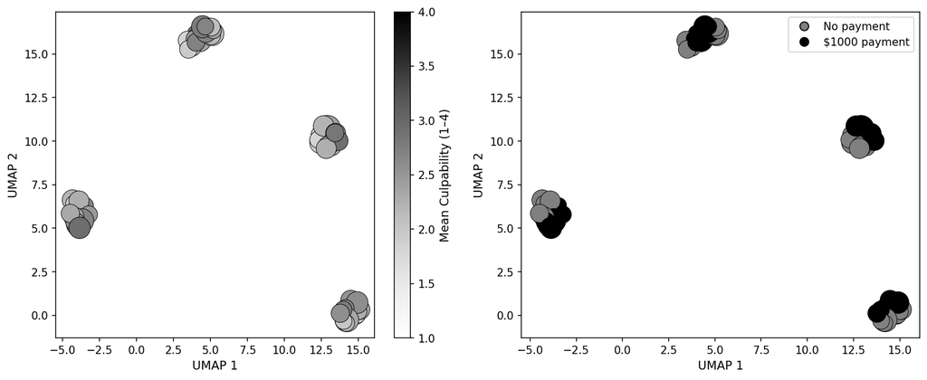

```
Saved: output/nlp/figures/fig_s2_umap_vignette_space.pdf
```

```python
# ── UMAP Figure: colored by Study 2 mean culpability ──
fig, axes = plt.subplots(1, 2, figsize=(12, 5))

# Panel A: Mean culpability (Study 2)
sc = axes[0].scatter(vignette_stats['umap_x'], vignette_stats['umap_y'],
                     c=vignette_stats['mean_culp'], cmap='Greys',
                     s=vignette_stats['n_trials'] * 15, edgecolors='black',
                     linewidth=0.5, vmin=1, vmax=4)
cbar = plt.colorbar(sc, ax=axes[0])
cbar.set_label('Mean Culpability (1–4)')
axes[0].set_xlabel('UMAP 1')
axes[0].set_ylabel('UMAP 2')

# Panel B: Colored by payment
colors_pay = ['grey' if p == 0 else 'black' for p in vignette_stats['payment_bin']]
axes[1].scatter(vignette_stats['umap_x'], vignette_stats['umap_y'],
                c=colors_pay, s=vignette_stats['n_trials'] * 15,
                edgecolors='black', linewidth=0.5)
axes[1].set_xlabel('UMAP 1')
axes[1].set_ylabel('UMAP 2')
legend_elements = [
    Line2D([0], [0], marker='o', color='w', markerfacecolor='grey',
           markersize=8, label='No payment', markeredgecolor='black'),
    Line2D([0], [0], marker='o', color='w', markerfacecolor='black',
           markersize=8, label='$1000 payment', markeredgecolor='black'),
]
axes[1].legend(handles=legend_elements, loc='best')

plt.tight_layout()
save_fig('fig_s2_umap_vignette_space.pdf')
```

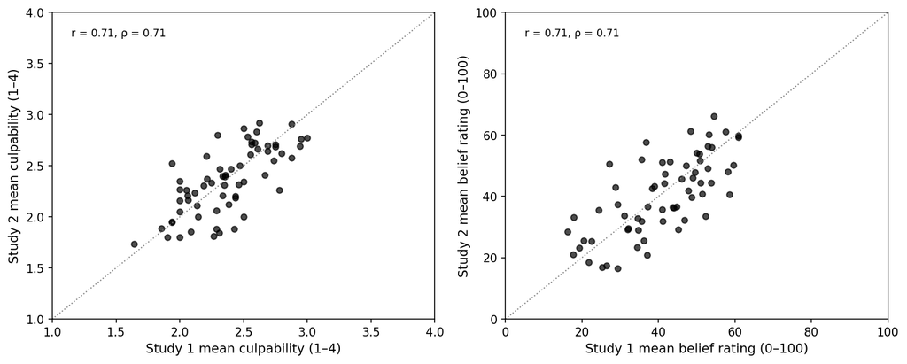

```
Saved: output/nlp/figures/fig_s2_vignette_means_s1_vs_s2.pdf
                                           Vignette mean  Pearson r   p (r)  Spearman rho p (rho)
                                  mean culpability (1–4)      0.709 < .0001         0.711 < .0001
                              mean belief rating (0–100)      0.711 < .0001         0.713 < .0001
Study 2 choice against Study 2 probe-defined culpability      0.793 < .0001         0.800 < .0001
Saved: output/nlp/vignette_means.csv
Saved: output/nlp/vignette_means_correlations.csv
```

```python
# ── Addition: vignette means in Study 1 against Study 2 ──
fig, axes = plt.subplots(1, 2, figsize=(11, 4.5))
cross_study = []
for ax, col, label, lims in [(axes[0], 'mean_culp', 'mean culpability (1–4)', (1, 4)),
                             (axes[1], 'mean_belief', 'mean belief rating (0–100)', (0, 100))]:
    x, y = vignette_stats_s1[col].values, vignette_stats[col].values
    r, p_r = stats.pearsonr(x, y)
    rho, p_rho = stats.spearmanr(x, y)
    cross_study.append({'Vignette mean': label, 'Pearson r': r, 'p (r)': p_r, 'Spearman rho': rho, 'p (rho)': p_rho})
    ax.scatter(x, y, s=25, color='black', alpha=0.7)
    ax.plot(lims, lims, linestyle=':', color='grey', linewidth=1)
    ax.set_xlim(lims); ax.set_ylim(lims)
    ax.set_xlabel(f'Study 1 {label}')
    ax.set_ylabel(f'Study 2 {label}')
    ax.annotate(f'r = {r:.2f}, ρ = {rho:.2f}', xy=(0.05, 0.95), xycoords='axes fraction', fontsize=9, va='top')
plt.tight_layout()
save_fig('fig_s2_vignette_means_s1_vs_s2.pdf')

r_cp, p_cp = stats.pearsonr(vignette_stats['mean_culp'], vignette_stats_probe['mean_culp'])
cross_study.append({'Vignette mean': 'Study 2 choice against Study 2 probe-defined culpability',
                    'Pearson r': r_cp, 'p (r)': p_cp,
                    'Spearman rho': stats.spearmanr(vignette_stats['mean_culp'], vignette_stats_probe['mean_culp'])[0],
                    'p (rho)': stats.spearmanr(vignette_stats['mean_culp'], vignette_stats_probe['mean_culp'])[1]})
cross_study = pd.DataFrame(cross_study)
print(cross_study.round(3).assign(**{c: cross_study[c].map(fmt_p) for c in ['p (r)', 'p (rho)']})
      .to_string(index=False))

vignette_means = pd.DataFrame({
    'vignette_id': VIGNETTE_IDS,
    **{c: vignette_stats[c] for c in FEATURE_COLS_NO_SLIDER},
    's1_trials': vignette_stats_s1['n_trials'], 's1_mean_culpability': vignette_stats_s1['mean_culp'],
    's1_mean_belief': vignette_stats_s1['mean_belief'],
    's2_trials': vignette_stats['n_trials'], 's2_mean_culpability': vignette_stats['mean_culp'],
    's2_mean_probe_culpability': vignette_stats_probe['mean_culp'], 's2_mean_belief': vignette_stats['mean_belief']})
save_table(vignette_means, 'vignette_means.csv')
save_table(cross_study, 'vignette_means_correlations.csv')
```

## 5. Random Forest Classification

As in Study 1, three random forests predict the four-level judgment. Model A uses only the six binary vignette features; it is the clean test of whether the objective stimulus properties alone predict the category, without the circularity of using a participant's own rating to predict that participant's choice. Model B adds the belief rating as a seventh predictor, and Model C uses the belief rating alone. B and C describe how the judgment relates to the participant's own estimate rather than what causes it, because the rating is itself a response. All three use 10-fold stratified cross-validation with balanced class weights, 500 trees and a minimum of five trials per leaf, and the folds are compared with paired t tests, as in the manuscript's Table A.3.

The same code runs on Study 1. Its results should equal the Study 1 notebook and Table A.3: features only .307 ± .035 (κ = .074), belief rating only .399 ± .035 (κ = .189), features and belief rating .473 ± .029 (κ = .254).

**Addition.** The three models are also fitted with Study 2's probe-defined category as the outcome.

```python
# ── Random forest settings (Study 1) and cross-validation ──
RF_PARAMS = dict(
    n_estimators=500, max_depth=None, min_samples_leaf=5,
    class_weight='balanced', random_state=SEED, n_jobs=-1
)

def cv_evaluate(model, X, y):
    # 10-fold stratified CV as in the Study 1 notebook. cross_val_predict refits the model on the same
    # folds that cross_val_score uses, so the per-fold accuracies equal the Study 1 notebook's.
    cv = StratifiedKFold(n_splits=10, shuffle=True, random_state=SEED)
    pred = cross_val_predict(model, X, y, cv=cv)
    folds = np.array([accuracy_score(y[test], pred[test]) for _, test in cv.split(X, y)])
    return {"pred": pred, "folds": folds, "acc": folds.mean(), "sd": folds.std(),
            "kappa": cohen_kappa_score(y, pred)}

MODEL_SPECS = {"A": ("Features only (6 predictors)", FEATURE_COLS_NO_SLIDER),
               "B": ("Features + belief rating (7 predictors)", FEATURE_COLS),
               "C": ("Belief rating only (1 predictor)", ["belief"])}

# The three outcomes: Study 1 (the rerun), Study 2, and Study 2's probe-defined category (addition).
OUTCOMES = {"Study 1": (d1, "culpability"),
            "Study 2": (d2, "culpability"),
            "Study 2 probe-defined": (d2, "probe_culpability")}

rf_res = {}
for label, (d, target) in OUTCOMES.items():
    t0 = time.time()
    y_out = d[target].values
    rf_res[label] = {"y": y_out}
    for k, (_, cols) in MODEL_SPECS.items():
        rf_res[label][k] = cv_evaluate(RandomForestClassifier(**RF_PARAMS), d[cols].values, y_out)
    print(f"{label}: three models cross-validated in {time.time() - t0:.0f} s")
```

```
Study 1: three models cross-validated in 34 s
Study 2: three models cross-validated in 37 s
Study 2 probe-defined: three models cross-validated in 36 s
```

```python
# ── Study 2: the three models, reported as in the Study 1 notebook ──
y = rf_res["Study 2"]["y"]
titles = {"A": "MODEL A: Features only (6 binary vignette features)",
          "B": "MODEL B: Features + belief rating (7 predictors)",
          "C": "MODEL C: Belief rating only (1 predictor)"}
for k in ["A", "B", "C"]:
    r = rf_res["Study 2"][k]
    print("═" * 60)
    print(titles[k])
    print("═" * 60)
    print(f"10-fold CV accuracy: {r['acc']:.3f} ± {r['sd']:.3f}")
    print(f"Cohen's κ: {r['kappa']:.3f}")
    if k == "A":
        print(f"  Chance: {1/4:.3f} (uniform) or {pd.Series(y).value_counts(normalize=True).max():.3f} (majority)")
    print()
    print(classification_report(y, r["pred"], target_names=JUDGMENT_ORDER))
    print()

# ── All three outcomes side by side, with the paired comparisons ──
rows, tests = [], []
for label, res in rf_res.items():
    y_out = res["y"]
    for k in ["A", "C", "B"]:
        r = res[k]
        rows.append({"Outcome": label, "Model": MODEL_SPECS[k][0], "Accuracy": r["acc"], "SD": r["sd"],
                     "Kappa": r["kappa"], "Knowledge recall": np.mean(r["pred"][y_out == 4] == 4),
                     "Majority rate": pd.Series(y_out).value_counts(normalize=True).max()})
    for a, b, name in [("A", "B", "features vs combined"), ("A", "C", "features vs belief only"),
                       ("C", "B", "belief only vs combined")]:
        t, p = stats.ttest_rel(res[a]["folds"], res[b]["folds"])
        tests.append({"Outcome": label, "Comparison": f"{a} vs {b} ({name})",
                      "Accuracy difference": res[b]["acc"] - res[a]["acc"], "t(9)": t, "p": p})
rf_table, rf_tests = pd.DataFrame(rows), pd.DataFrame(tests)
print("═" * 60)
print("THREE-WAY COMPARISON, ALL OUTCOMES")
print("═" * 60)
print(rf_table.round(3).to_string(index=False))
print()
print(rf_tests.round(3).assign(p=rf_tests["p"].map(fmt_p)).to_string(index=False))
print()
print("Study 1 notebook and manuscript Table A.3: A .307 ± .035 (κ .074), C .399 ± .035 (κ .189), "
      "B .473 ± .029 (κ .254); A vs B t(9) = -11.15, A vs C t(9) = -5.86, C vs B t(9) = -6.82; "
      "Knowledge recall 15.2% (A) and 12.4% (B).")
save_table(rf_table, "rf_cv_accuracy.csv")
save_table(rf_tests, "rf_paired_tests.csv")
```

```
════════════════════════════════════════════════════════════
MODEL A: Features only (6 binary vignette features)
════════════════════════════════════════════════════════════
10-fold CV accuracy: 0.395 ± 0.028
Cohen's κ: 0.176
  Chance: 0.250 (uniform) or 0.491 (majority)

               precision    recall  f1-score   support

Blamelessness       0.24      0.47      0.32       158
   Negligence       0.65      0.35      0.45       643
 Recklessness       0.46      0.50      0.48       376
    Knowledge       0.13      0.23      0.17       133

     accuracy                           0.40      1310
    macro avg       0.37      0.39      0.35      1310
 weighted avg       0.49      0.40      0.41      1310


════════════════════════════════════════════════════════════
MODEL B: Features + belief rating (7 predictors)
════════════════════════════════════════════════════════════
10-fold CV accuracy: 0.481 ± 0.048
Cohen's κ: 0.248

               precision    recall  f1-score   support

Blamelessness       0.29      0.49      0.36       158
   Negligence       0.62      0.47      0.53       643
 Recklessness       0.54      0.60      0.57       376
    Knowledge       0.19      0.20      0.19       133

     accuracy                           0.48      1310
    macro avg       0.41      0.44      0.41      1310
 weighted avg       0.51      0.48      0.49      1310


════════════════════════════════════════════════════════════
MODEL C: Belief rating only (1 predictor)
════════════════════════════════════════════════════════════
```

[output cut: 28 more lines]

```

              Outcome                       Comparison  Accuracy difference    t(9)       p
              Study 1    A vs B (features vs combined)                0.166 -11.146 < .0001
              Study 1 A vs C (features vs belief only)                0.092  -5.861  0.0002
              Study 1 C vs B (belief only vs combined)                0.074  -6.824 < .0001
              Study 2    A vs B (features vs combined)                0.085  -6.752 < .0001
              Study 2 A vs C (features vs belief only)               -0.032   3.174  0.0113
              Study 2 C vs B (belief only vs combined)                0.118  -9.423 < .0001
Study 2 probe-defined    A vs B (features vs combined)                0.089  -5.291  0.0005
Study 2 probe-defined A vs C (features vs belief only)                0.030  -1.857  0.0963
Study 2 probe-defined C vs B (belief only vs combined)                0.060  -3.259  0.0099

Study 1 notebook and manuscript Table A.3: A .307 ± .035 (κ .074), C .399 ± .035 (κ .189), B .473 ± .029 (κ .254); A vs B t(9) = -11.15, A vs C t(9) = -5.86, C vs B t(9) = -6.82; Knowledge recall 15.2% (A) and 12.4% (B).
Saved: output/nlp/rf_cv_accuracy.csv
Saved: output/nlp/rf_paired_tests.csv
```

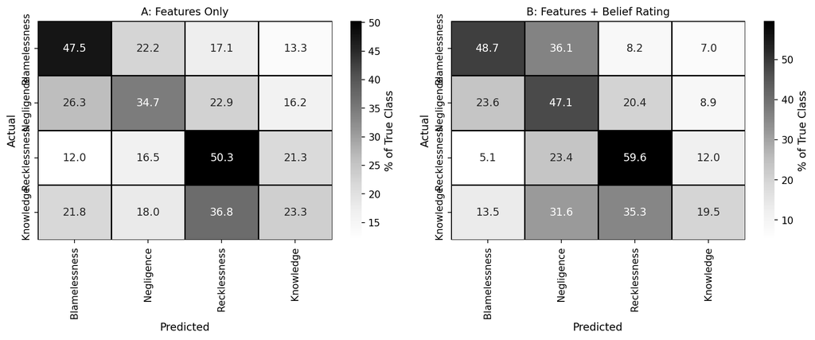

```
Saved: output/nlp/figures/fig_s2_rf_confusion_matrix.pdf
```

```python
# ── Confusion matrices for both models (Study 2) ──
y = rf_res["Study 2"]["y"]
fig, axes = plt.subplots(1, 2, figsize=(12, 5))

for ax, y_pred, title in [
    (axes[0], rf_res["Study 2"]["A"]["pred"], 'A: Features Only'),
    (axes[1], rf_res["Study 2"]["B"]["pred"], 'B: Features + Belief Rating')
]:
    cm = confusion_matrix(y, y_pred)
    cm_pct = cm.astype(float) / cm.sum(axis=1, keepdims=True) * 100
    sns.heatmap(cm_pct, annot=True, fmt='.1f', cmap='Greys',
                xticklabels=JUDGMENT_ORDER, yticklabels=JUDGMENT_ORDER,
                cbar_kws={'label': '% of True Class'}, linewidths=0.5,
                linecolor='black', ax=ax)
    ax.set_xlabel('Predicted')
    ax.set_ylabel('Actual')
    ax.set_title(title, fontsize=11)

plt.tight_layout()
save_fig('fig_s2_rf_confusion_matrix.pdf')
```

## 6. SHAP Feature Importance

As in Study 1, SHAP values are computed with TreeExplainer (exact for tree models) for both Study 2 forests fitted to all trials: the features-only model, which shows which objective vignette features drive the classification without the belief rating, and the full model, which shows the weight of the participant's own estimate. The figures are the Study 1 set: global bar plots for both models, an overall importance bar, a beeswarm plot for each category and the category-by-feature heatmap.

```python
# ── Fit both RF models on all Study 2 trials for SHAP ──
def shap_3d(sv):
    # TreeExplainer output as an array (trials, features, classes), whatever form the shap version returns.
    if isinstance(sv, list):
        sv = np.array(sv).transpose(1, 2, 0)
    return sv

X_feat = d2[FEATURE_COLS_NO_SLIDER].values
X_full = d2[FEATURE_COLS].values
y = d2["culpability"].values

rf_feat_full = RandomForestClassifier(**RF_PARAMS).fit(X_feat, y)
rf_all_full = RandomForestClassifier(**RF_PARAMS).fit(X_full, y)

# ── SHAP for features-only model (primary) ──
explainer_feat = shap.TreeExplainer(rf_feat_full)
shap_values_feat = shap_3d(explainer_feat.shap_values(X_feat))
X_display_feat = pd.DataFrame(X_feat, columns=FEATURE_LABELS_NO_SLIDER)
print(f"Features-only SHAP shape: {shap_values_feat.shape}")

# ── SHAP for full model (secondary) ──
explainer_full = shap.TreeExplainer(rf_all_full)
shap_values_full = shap_3d(explainer_full.shap_values(X_full))
X_display_full = pd.DataFrame(X_full, columns=FEATURE_LABELS)
print(f"Full model SHAP shape: {shap_values_full.shape}")
```

```
Features-only SHAP shape: (1310, 6, 4)
Full model SHAP shape: (1310, 7, 4)
```

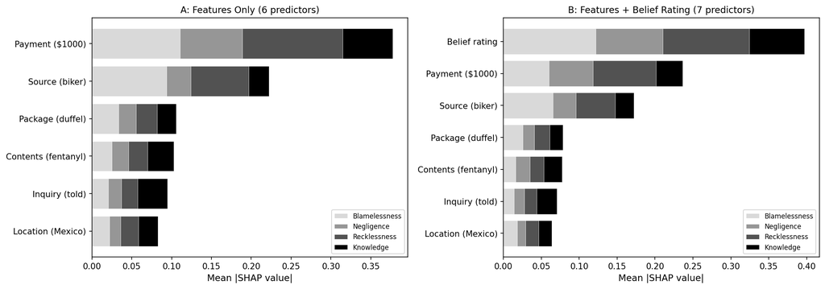

```
Saved: output/nlp/figures/fig_s2_shap_bar_global.pdf
```

```python
# ── Global SHAP bar plots: computed manually for full control ──
# shap.summary_plot manages its own figure internally and ignores pre-created
# axes, so we compute mean |SHAP| per class ourselves and plot with matplotlib.
fig, axes = plt.subplots(1, 2, figsize=(14, 5))
gray_shades = ['#d9d9d9', '#969696', '#525252', '#000000']

for ax, sv, labels, title in [
    (axes[0], shap_values_feat, FEATURE_LABELS_NO_SLIDER, 'A: Features Only (6 predictors)'),
    (axes[1], shap_values_full, FEATURE_LABELS, 'B: Features + Belief Rating (7 predictors)')
]:
    mean_shap = np.mean(np.abs(sv), axis=0)           # (n_features, n_classes)
    bottom = np.zeros(mean_shap.shape[0])
    sorted_idx = np.argsort(mean_shap.mean(axis=1))   # sort by overall importance
    for c in range(mean_shap.shape[1]):
        ax.barh(np.arange(len(sorted_idx)), mean_shap[sorted_idx, c],
                left=bottom[sorted_idx], color=gray_shades[c],
                edgecolor='white', linewidth=0.3, label=JUDGMENT_ORDER[c])
        bottom += mean_shap[:, c]
    ax.set_yticks(np.arange(len(sorted_idx)))
    ax.set_yticklabels([labels[i] for i in sorted_idx])
    ax.set_xlabel('Mean |SHAP value|')
    ax.set_title(title, fontsize=11)
    ax.legend(fontsize=8, loc='lower right')

plt.tight_layout()
save_fig('fig_s2_shap_bar_global.pdf')
```

```
            Feature  Mean |SHAP|
    Payment ($1000)        0.094
     Source (biker)        0.056
   Package (duffel)        0.026
Contents (fentanyl)        0.026
     Inquiry (told)        0.024
  Location (Mexico)        0.021
```

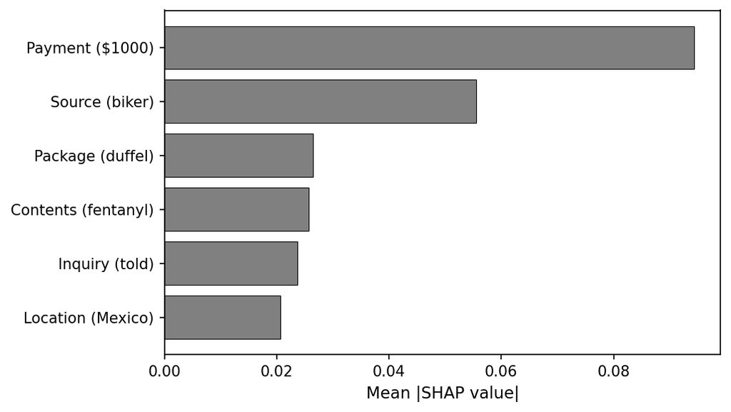

```
Saved: output/nlp/figures/fig_s2_shap_importance_bar.pdf
```

```python
# ── Mean |SHAP| bar plot: features-only model ──
mean_abs_shap = np.mean(np.abs(shap_values_feat), axis=(0, 2))
importance_df = pd.DataFrame({
    'Feature': FEATURE_LABELS_NO_SLIDER,
    'Mean |SHAP|': mean_abs_shap
}).sort_values('Mean |SHAP|', ascending=True)
print(importance_df.sort_values('Mean |SHAP|', ascending=False).round(3).to_string(index=False))

fig, ax = plt.subplots(figsize=(7, 4))
ax.barh(importance_df['Feature'], importance_df['Mean |SHAP|'],
        color='grey', edgecolor='black', linewidth=0.5)
ax.set_xlabel('Mean |SHAP value|')
plt.tight_layout()
save_fig('fig_s2_shap_importance_bar.pdf')
```

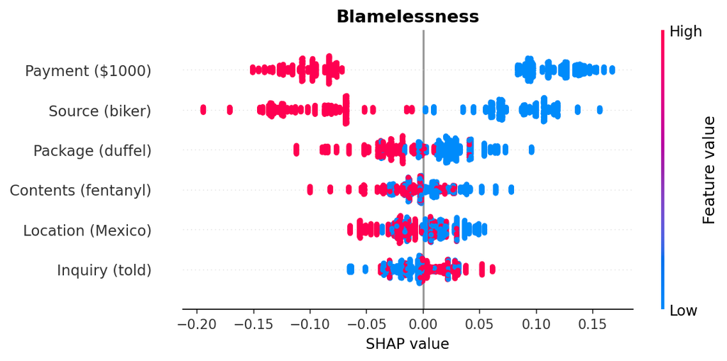

```
Saved: output/nlp/figures/fig_s2_shap_blamelessness.pdf
```

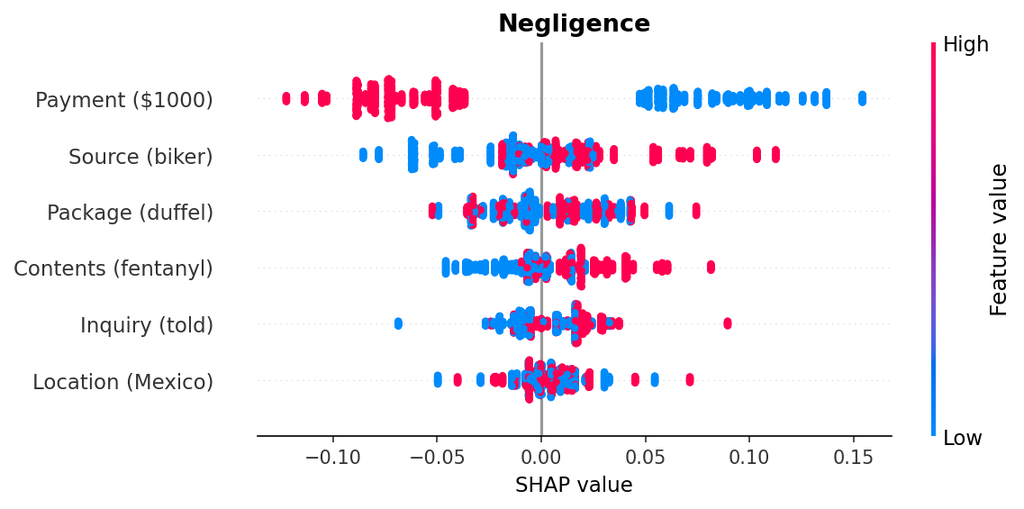

```
Saved: output/nlp/figures/fig_s2_shap_negligence.pdf
```

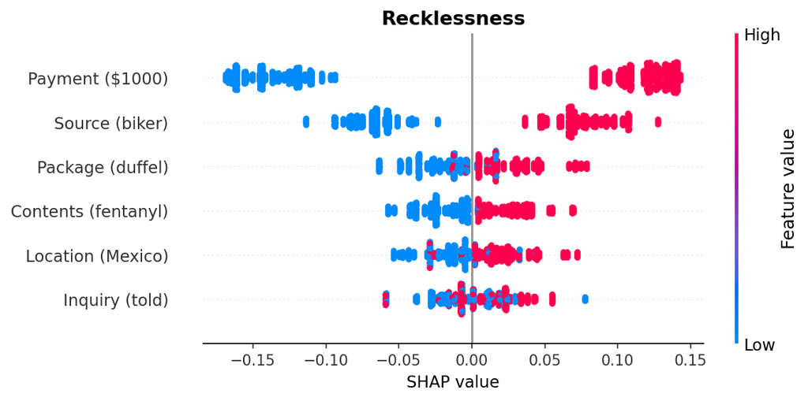

```
Saved: output/nlp/figures/fig_s2_shap_recklessness.pdf
```

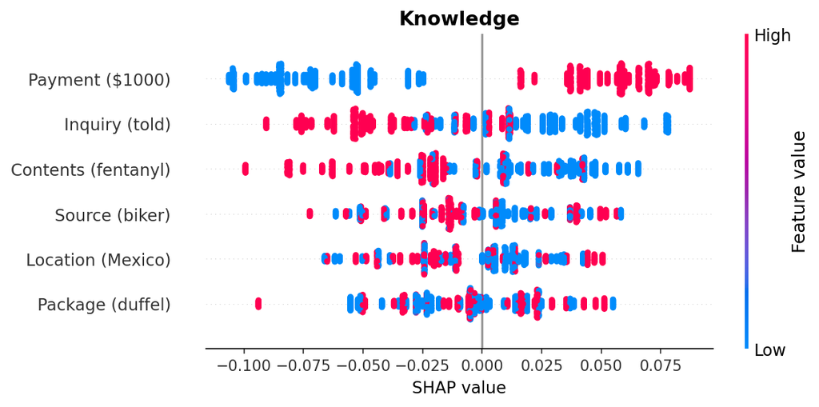

```
Saved: output/nlp/figures/fig_s2_shap_knowledge.pdf
```

```python
# ── Per-class SHAP beeswarm plots (features-only model) ──
# Each class gets its own figure to avoid SHAP's internal figure management
# conflicting with subplot layouts, as in the Study 1 notebook.
for i, label in enumerate(JUDGMENT_ORDER):
    fig, ax = plt.subplots(figsize=(7, 4))
    shap.summary_plot(shap_values_feat[:, :, i], X_display_feat,
                      plot_type='dot', show=False, max_display=6,
                      color_bar=True)
    ax.set_title(label, fontsize=13, fontweight='bold')
    ax.set_xlabel('SHAP value', fontsize=11)
    ax.tick_params(axis='y', labelsize=11)
    ax.tick_params(axis='x', labelsize=10)
    plt.tight_layout()
    save_fig(f'fig_s2_shap_{label.lower()}.pdf')
    print()
```

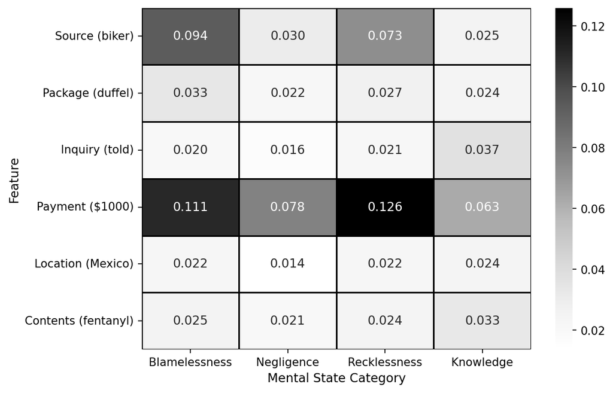

```
Saved: output/nlp/figures/fig_s2_shap_class_heatmap.pdf
```

```python
# ── Per-class mean |SHAP| heatmap (features-only model) ──
class_importance_s2 = np.mean(np.abs(shap_values_feat), axis=0)   # (n_features, n_classes)
heatmap_df = pd.DataFrame(class_importance_s2, index=FEATURE_LABELS_NO_SLIDER, columns=JUDGMENT_ORDER)

fig, ax = plt.subplots(figsize=(8, 5))
sns.heatmap(heatmap_df, annot=True, fmt='.3f', cmap='Greys',
            linewidths=0.5, linecolor='black', ax=ax)
ax.set_ylabel('Feature')
ax.set_xlabel('Mental State Category')
plt.tight_layout()
save_fig('fig_s2_shap_class_heatmap.pdf')
```

### Does the Study 1 pattern replicate?

In Study 1 the category-specific importances differed: source led for Blamelessness (mean |SHAP| = .115, payment second at .070), payment led for Negligence (.057) and Recklessness (.088), and contents led for Knowledge (.049, ahead of payment at .042), which the manuscript read as participants inferring knowledge from what was in the package. The cell below fits the same features-only forest to each outcome (Study 1, Study 2, and, as an addition, Study 2's probe-defined category) and sets the three importance tables side by side.

The six binary features take at most 64 distinct values, and a trial's SHAP values depend only on its feature values, so the mean over trials is computed from the distinct feature rows weighted by how often each occurs. The result equals the mean over all trials (the cell checks this against the Study 2 values above) and is about twenty times faster, which makes the bootstrap below practical.

```
── Study 1: mean |SHAP| by feature (rows) and category (columns) ──
                     Blamelessness  Negligence  Recklessness  Knowledge
Source (biker)               0.115       0.047         0.070      0.021
Package (duffel)             0.041       0.016         0.033      0.014
Inquiry (told)               0.022       0.034         0.016      0.030
Payment ($1000)              0.070       0.057         0.088      0.042
Location (Mexico)            0.021       0.016         0.015      0.021
Contents (fentanyl)          0.034       0.024         0.027      0.049

── Study 2: mean |SHAP| by feature (rows) and category (columns) ──
                     Blamelessness  Negligence  Recklessness  Knowledge
Source (biker)               0.094       0.030         0.073      0.025
Package (duffel)             0.033       0.022         0.027      0.024
Inquiry (told)               0.020       0.016         0.021      0.037
Payment ($1000)              0.111       0.078         0.126      0.063
Location (Mexico)            0.022       0.014         0.022      0.024
Contents (fentanyl)          0.025       0.021         0.024      0.033

── Study 2 probe-defined: mean |SHAP| by feature (rows) and category (columns) ──
                     Blamelessness  Negligence  Recklessness  Knowledge
Source (biker)               0.078       0.025         0.035      0.025
Package (duffel)             0.025       0.018         0.018      0.019
Inquiry (told)               0.015       0.017         0.020      0.021
Payment ($1000)              0.105       0.061         0.077      0.089
Location (Mexico)            0.020       0.021         0.028      0.015
Contents (fentanyl)          0.018       0.017         0.019      0.020

              Outcome      Category               First  First |SHAP|          Second  Second |SHAP|  Contents |SHAP|  Payment |SHAP|
              Study 1 Blamelessness      Source (biker)         0.115 Payment ($1000)          0.070            0.034           0.070
              Study 1    Negligence     Payment ($1000)         0.057  Source (biker)          0.047            0.024           0.057
              Study 1  Recklessness     Payment ($1000)         0.088  Source (biker)          0.070            0.027           0.088
              Study 1     Knowledge Contents (fentanyl)         0.049 Payment ($1000)          0.042            0.049           0.042
              Study 2 Blamelessness     Payment ($1000)         0.111  Source (biker)          0.094            0.025           0.111
              Study 2    Negligence     Payment ($1000)         0.078  Source (biker)          0.030            0.021           0.078
              Study 2  Recklessness     Payment ($1000)         0.126  Source (biker)          0.073            0.024           0.126
              Study 2     Knowledge     Payment ($1000)         0.063  Inquiry (told)          0.037            0.033           0.063
Study 2 probe-defined Blamelessness     Payment ($1000)         0.105  Source (biker)          0.078            0.018           0.105
Study 2 probe-defined    Negligence     Payment ($1000)         0.061  Source (biker)          0.025            0.017           0.061
Study 2 probe-defined  Recklessness     Payment ($1000)         0.077  Source (biker)          0.035            0.019           0.077
Study 2 probe-defined     Knowledge     Payment ($1000)         0.089  Source (biker)          0.025            0.020           0.089

Study 1 manuscript: Blamelessness, Source .115 (Payment .070); Negligence, Payment .057; Recklessness, Payment .088; Knowledge, Contents .049 (Payment .042).
Saved: output/nlp/shap_class_importance.csv
Saved: output/nlp/shap_top_features.csv
```

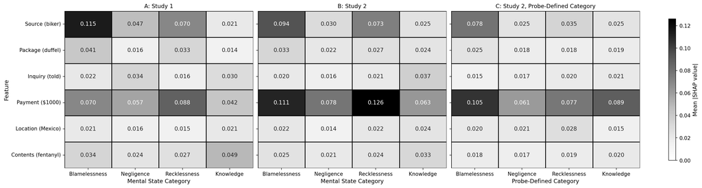

```
Saved: output/nlp/figures/fig_s2_shap_class_heatmap_comparison.pdf
```

```python
# ── Class-specific importance for all three outcomes ──
def class_importance(model, X):
    # Mean |SHAP| for each feature (rows) and category (columns) over the trials in X, computed from the
    # distinct feature rows weighted by their counts. Equal to the mean over all trials.
    rows, counts = np.unique(X, axis=0, return_counts=True)
    sv = np.abs(shap_3d(shap.TreeExplainer(model).shap_values(rows)))
    assert sv.shape[2] == len(JUDGMENT_ORDER), "every category must occur in the data"
    return np.tensordot(counts / counts.sum(), sv, axes=1)

importance = {}
for label, (d, target) in OUTCOMES.items():
    X = d[FEATURE_COLS_NO_SLIDER].values
    m = RandomForestClassifier(**RF_PARAMS).fit(X, d[target].values)
    importance[label] = pd.DataFrame(class_importance(m, X), index=FEATURE_LABELS_NO_SLIDER, columns=JUDGMENT_ORDER)
assert np.allclose(importance["Study 2"].values, class_importance_s2), "shortcut differs from the mean over trials"

for label, imp in importance.items():
    print(f"── {label}: mean |SHAP| by feature (rows) and category (columns) ──")
    print(imp.round(3).to_string())
    print()

rows = []
for label, imp in importance.items():
    for cls in JUDGMENT_ORDER:
        s = imp[cls].sort_values(ascending=False)
        rows.append({"Outcome": label, "Category": cls, "First": s.index[0], "First |SHAP|": s.iloc[0],
                     "Second": s.index[1], "Second |SHAP|": s.iloc[1],
                     "Contents |SHAP|": imp.loc["Contents (fentanyl)", cls],
                     "Payment |SHAP|": imp.loc["Payment ($1000)", cls]})
top_features = pd.DataFrame(rows)
print(top_features.round(3).to_string(index=False))
print()
print("Study 1 manuscript: Blamelessness, Source .115 (Payment .070); Negligence, Payment .057; "
      "Recklessness, Payment .088; Knowledge, Contents .049 (Payment .042).")

long = pd.concat([imp.reset_index(names="Feature").melt(id_vars="Feature", var_name="Category",
                                                           value_name="Mean |SHAP|").assign(Outcome=label)
                  for label, imp in importance.items()])[["Outcome", "Feature", "Category", "Mean |SHAP|"]]
save_table(long, "shap_class_importance.csv")
save_table(top_features, "shap_top_features.csv")

# ── Side-by-side heatmaps with one shared scale ──
vmax = max(imp.values.max() for imp in importance.values())
fig, axes = plt.subplots(1, 3, figsize=(19, 5), constrained_layout=True)
for ax, (label, imp), title in zip(axes, importance.items(),
                                   ['A: Study 1', 'B: Study 2', 'C: Study 2, Probe-Defined Category']):
    sns.heatmap(imp, annot=True, fmt='.3f', cmap='Greys', vmin=0, vmax=vmax,
                linewidths=0.5, linecolor='black', ax=ax, cbar=False)
    ax.set_xlabel('Probe-Defined Category' if 'probe' in label else 'Mental State Category')
    ax.set_ylabel('Feature' if ax is axes[0] else '')
    ax.set_xticklabels(ax.get_xticklabels(), rotation=0)
    if ax is not axes[0]:
        ax.set_yticklabels([])
    ax.set_title(title, fontsize=11)
fig.colorbar(axes[0].collections[0], ax=axes, shrink=0.9, label='Mean |SHAP value|')
save_fig('fig_s2_shap_class_heatmap_comparison.pdf')
```

**Addition: the plain percentages behind the Knowledge importances.** A mean |SHAP| value is a size without a direction: it says how much a feature moves the predicted probability of a category, not whether it raises or lowers it. The table below shows the same information without a model and with the direction: the percentage of trials classified as Knowledge at each level of each feature, and the difference in percentage points (level 1 minus level 0). A feature that SHAP ranks first for Knowledge should show the largest difference, and the sign shows which way it works.

```python
# ── Percentage of Knowledge at each level of each feature ──
rows = []
for label, (d, target) in OUTCOMES.items():
    is_knowledge = (d[target] == 4)
    for col, name in zip(FEATURE_COLS_NO_SLIDER, FEATURE_LABELS_NO_SLIDER):
        p0, p1 = 100 * is_knowledge[d[col] == 0].mean(), 100 * is_knowledge[d[col] == 1].mean()
        rows.append({"Outcome": label, "Feature": name, "Knowledge % (level 0)": p0,
                     "Knowledge % (level 1)": p1, "Difference (points)": p1 - p0})
knowledge_rates = pd.DataFrame(rows)
print(knowledge_rates.pivot(index="Feature", columns="Outcome", values="Difference (points)")
      .reindex(FEATURE_LABELS_NO_SLIDER)[list(OUTCOMES)].round(1).to_string())
print()
print(knowledge_rates.round(1).to_string(index=False))
save_table(knowledge_rates, "knowledge_rates_by_feature.csv")
```

```
Outcome              Study 1  Study 2  Study 2 probe-defined
Feature
Source (biker)          -2.0     -1.5                    4.5
Package (duffel)        -0.6      0.1                   -1.3
Inquiry (told)          -3.7     -3.0                   -0.3
Payment ($1000)          4.7      6.0                   19.1
Location (Mexico)       -0.9     -0.3                   -0.2
Contents (fentanyl)     -6.0     -2.8                    1.7

              Outcome             Feature  Knowledge % (level 0)  Knowledge % (level 1)  Difference (points)
              Study 1      Source (biker)                   14.7                   12.7                 -2.0
              Study 1    Package (duffel)                   14.0                   13.4                 -0.6
              Study 1      Inquiry (told)                   15.5                   11.8                 -3.7
              Study 1     Payment ($1000)                   11.3                   16.0                  4.7
              Study 1   Location (Mexico)                   14.1                   13.2                 -0.9
              Study 1 Contents (fentanyl)                   16.7                   10.7                 -6.0
              Study 2      Source (biker)                   10.9                    9.4                 -1.5
              Study 2    Package (duffel)                   10.1                   10.2                  0.1
              Study 2      Inquiry (told)                   11.6                    8.7                 -3.0
              Study 2     Payment ($1000)                    7.0                   13.0                  6.0
              Study 2   Location (Mexico)                   10.3                   10.0                 -0.3
              Study 2 Contents (fentanyl)                   11.5                    8.8                 -2.8
Study 2 probe-defined      Source (biker)                   22.5                   27.0                  4.5
Study 2 probe-defined    Package (duffel)                   25.4                   24.1                 -1.3
Study 2 probe-defined      Inquiry (told)                   25.0                   24.7                 -0.3
Study 2 probe-defined     Payment ($1000)                   14.9                   33.9                 19.1
Study 2 probe-defined   Location (Mexico)                   24.9                   24.7                 -0.2
Study 2 probe-defined Contents (fentanyl)                   24.0                   25.7                  1.7
Saved: output/nlp/knowledge_rates_by_feature.csv
```

```python
# ── Participant bootstrap of the class-specific importance ──
def bootstrap_importance(d, target, n_boot=N_BOOT, seed=SEED):
    rng = np.random.default_rng(seed)
    people = list(d.groupby("pid").indices.values())        # row positions of each person's five trials
    X_all, y_all = d[FEATURE_COLS_NO_SLIDER].values, d[target].values
    out = np.empty((n_boot, len(FEATURE_COLS_NO_SLIDER), len(JUDGMENT_ORDER)))
    for b in range(n_boot):
        idx = np.concatenate([people[i] for i in rng.integers(0, len(people), len(people))])
        m = RandomForestClassifier(**dict(RF_PARAMS, random_state=SEED + 1 + b)).fit(X_all[idx], y_all[idx])
        out[b] = class_importance(m, X_all[idx])
    return out

boot = {}
for label, (d, target) in OUTCOMES.items():
    t0 = time.time()
    boot[label] = bootstrap_importance(d, target)
    print(f"{label}: {N_BOOT} resamples in {time.time() - t0:.0f} s")

# ── How often each feature ranks first, by outcome and category ──
rows = []
for label, B in boot.items():
    first = B.argmax(axis=1)                                  # (n_boot, n_classes): index of the top feature
    for c, cls in enumerate(JUDGMENT_ORDER):
        rows.append({"Outcome": label, "Category": cls,
                     **{name: 100 * np.mean(first[:, c] == f) for f, name in enumerate(FEATURE_LABELS_NO_SLIDER)}})
rank_first = pd.DataFrame(rows)
print()
print("Percentage of resamples in which each feature ranks first:")
print(rank_first.round(0).to_string(index=False))

# ── Knowledge: contents against payment ──
K = JUDGMENT_ORDER.index("Knowledge")
ci_, pi_ = FEATURE_LABELS_NO_SLIDER.index("Contents (fentanyl)"), FEATURE_LABELS_NO_SLIDER.index("Payment ($1000)")
rows = []
for label, B in boot.items():
    kb = B[:, :, K]
    diff = kb[:, ci_] - kb[:, pi_]
    lo, hi = np.percentile(diff, [2.5, 97.5])
    rows.append({"Outcome": label,
                 "Contents |SHAP|": importance[label].iloc[ci_, K],
                 "Payment |SHAP|": importance[label].iloc[pi_, K],
                 "Contents minus payment": importance[label].iloc[ci_, K] - importance[label].iloc[pi_, K],
                 "95% bootstrap interval": f"[{lo:.3f}, {hi:.3f}]",
                 "Contents > payment (% of resamples)": 100 * np.mean(diff > 0)})
knowledge_boot = pd.DataFrame(rows)
print()
print("Knowledge: contents against payment")
print(knowledge_boot.round(3).to_string(index=False))

boot_long = pd.DataFrame([{"Outcome": label, "Resample": b + 1, "Feature": FEATURE_LABELS_NO_SLIDER[f],
                           "Category": JUDGMENT_ORDER[c], "Mean |SHAP|": B[b, f, c]}
                          for label, B in boot.items() for b in range(B.shape[0])
                          for f in range(B.shape[1]) for c in range(B.shape[2])])
save_table(boot_long, "shap_bootstrap.csv")
save_table(rank_first, "shap_bootstrap_rank_first.csv")
save_table(knowledge_boot, "shap_bootstrap_knowledge.csv")
```

```
Study 1: 200 resamples in 308 s
Study 2: 200 resamples in 307 s
Study 2 probe-defined: 200 resamples in 303 s

Percentage of resamples in which each feature ranks first:
              Outcome      Category  Source (biker)  Package (duffel)  Inquiry (told)  Payment ($1000)  Location (Mexico)  Contents (fentanyl)
              Study 1 Blamelessness            98.0               0.0             0.0              2.0                0.0                  0.0
              Study 1    Negligence            22.0               0.0             5.0             72.0                0.0                  0.0
              Study 1  Recklessness            18.0               0.0             0.0             82.0                0.0                  0.0
              Study 1     Knowledge             0.0               0.0             4.0             28.0                0.0                 66.0
              Study 2 Blamelessness            26.0               0.0             0.0             74.0                0.0                  0.0
              Study 2    Negligence             0.0               0.0             0.0             99.0                0.0                  0.0
              Study 2  Recklessness             1.0               0.0             0.0             99.0                0.0                  0.0
              Study 2     Knowledge             3.0               2.0            10.0             82.0                0.0                  3.0
Study 2 probe-defined Blamelessness             6.0               0.0             0.0             94.0                0.0                  0.0
Study 2 probe-defined    Negligence             2.0               0.0             0.0             98.0                0.0                  0.0
Study 2 probe-defined  Recklessness             2.0               0.0             0.0             98.0                0.0                  0.0
Study 2 probe-defined     Knowledge             0.0               0.0             0.0            100.0                0.0                  0.0

Knowledge: contents against payment
              Outcome  Contents |SHAP|  Payment |SHAP|  Contents minus payment 95% bootstrap interval  Contents > payment (% of resamples)
              Study 1            0.049           0.042                   0.007        [-0.025, 0.034]                                 69.0
              Study 2            0.033           0.063                  -0.030        [-0.062, 0.006]                                  8.5
Study 2 probe-defined            0.020           0.089                  -0.069       [-0.086, -0.033]                                  0.0
Saved: output/nlp/shap_bootstrap.csv
Saved: output/nlp/shap_bootstrap_rank_first.csv
Saved: output/nlp/shap_bootstrap_knowledge.csv
```

The figure shows, for the Knowledge category, each feature's importance in all trials (bars) and the range of the middle 95% of its bootstrap values (lines). The ranges sit somewhat to the right of the bars: a resample repeats some people, which lets the forest fit their answers more closely and inflates every mean |SHAP| value. The inflation applies to all six features within a resample, so the rankings and the contents-against-payment percentages above, which compare features within each resample, are the quantities to read.

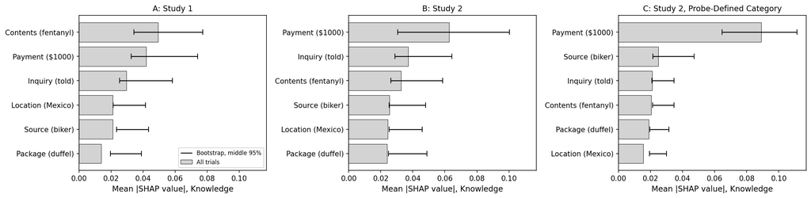

```
Saved: output/nlp/figures/fig_s2_shap_knowledge_bootstrap.pdf
```

```python
# ── Knowledge importance in all trials, with the bootstrap range, by outcome ──
fig, axes = plt.subplots(1, 3, figsize=(16, 4), sharex=True)
for ax, (label, B), title in zip(axes, boot.items(),
                                 ['A: Study 1', 'B: Study 2', 'C: Study 2, Probe-Defined Category']):
    est = importance[label]['Knowledge'].values
    lo, hi = np.percentile(B[:, :, K], [2.5, 97.5], axis=0)
    order = np.argsort(est)
    ypos = np.arange(len(order))
    ax.barh(ypos, est[order], color='lightgrey', edgecolor='black', linewidth=0.5, label='All trials')
    ax.hlines(ypos, lo[order], hi[order], color='black', linewidth=1.2, label='Bootstrap, middle 95%')
    ax.plot(lo[order], ypos, '|', color='black', markersize=8)
    ax.plot(hi[order], ypos, '|', color='black', markersize=8)
    ax.set_yticks(ypos)
    ax.set_yticklabels([FEATURE_LABELS_NO_SLIDER[i] for i in order])
    ax.set_xlabel('Mean |SHAP value|, Knowledge')
    ax.set_title(title, fontsize=11)
    if ax is axes[0]:
        ax.legend(fontsize=8, loc='lower right')
plt.tight_layout()
save_fig('fig_s2_shap_knowledge_bootstrap.pdf')
```

## 7. SHAP Dependence and Interaction Effects

Dependence plots show how the SHAP value for a feature varies with the feature's value; for binary features this gives two clusters of points, and color marks the feature SHAP selects as the strongest interaction. As in Study 1, the plots are for the Recklessness class and show the two features with the highest overall importance in the features-only model (in Study 1, payment and source; here they are chosen from the Study 2 values). The interaction heatmap uses the first 200 trials, as in Study 1.

```
The two most important features overall in Study 2: Payment ($1000), Source (biker) (Study 1: Payment ($1000) and Source (biker))
```

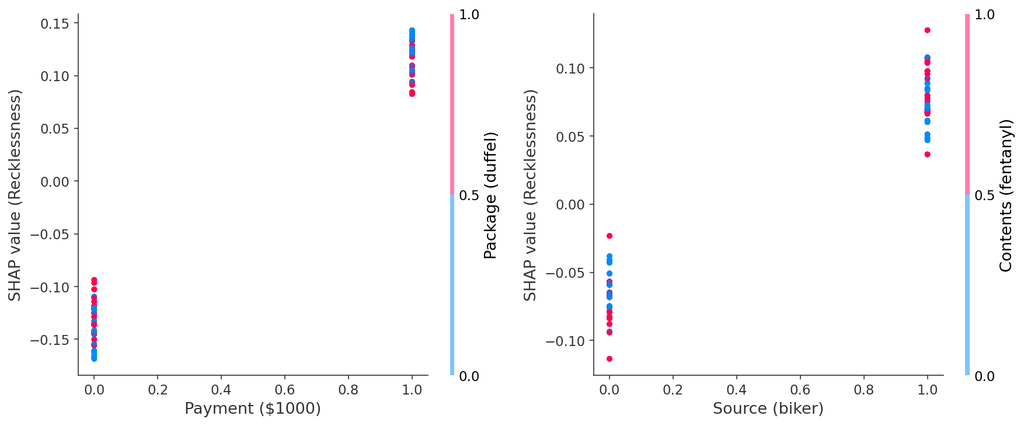

```
Saved: output/nlp/figures/fig_s2_shap_dependence.pdf
```

```python
# ── SHAP dependence plots for the two most important features (Recklessness class) ──
overall = np.mean(np.abs(shap_values_feat), axis=(0, 2))
top_two = [FEATURE_LABELS_NO_SLIDER[i] for i in np.argsort(-overall)[:2]]
print("The two most important features overall in Study 2:", ", ".join(top_two),
      "(Study 1: Payment ($1000) and Source (biker))")
R = JUDGMENT_ORDER.index('Recklessness')

fig, axes = plt.subplots(1, 2, figsize=(12, 5))
for ax, feature in zip(axes, top_two):
    shap.dependence_plot(feature, shap_values_feat[:, :, R], X_display_feat,
                         interaction_index='auto', ax=ax, show=False,
                         dot_size=20, alpha=0.5)
    ax.set_ylabel('SHAP value (Recklessness)')
plt.tight_layout()
save_fig('fig_s2_shap_dependence.pdf')
```

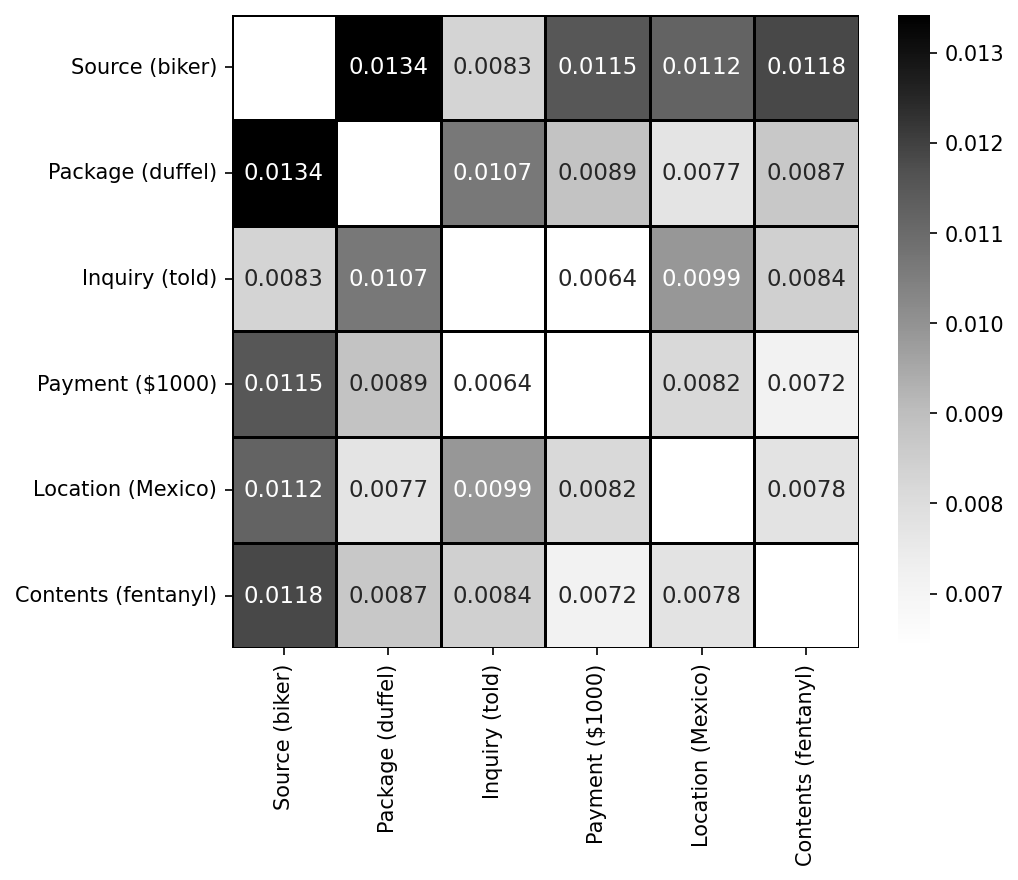

```
Saved: output/nlp/figures/fig_s2_shap_interactions.pdf
```

```python
# ── SHAP interaction values (features-only model) ──
n_interaction_samples = min(200, len(X_feat))
X_sample = X_feat[:n_interaction_samples]

shap_interaction = explainer_feat.shap_interaction_values(X_sample)
if isinstance(shap_interaction, list):
    shap_interaction = np.array(shap_interaction).transpose(1, 2, 3, 0)

mean_interactions = (np.mean(np.abs(shap_interaction), axis=(0, 3))
                     if shap_interaction.ndim == 4
                     else np.mean(np.abs(shap_interaction), axis=0))
np.fill_diagonal(mean_interactions, 0)

interaction_df = pd.DataFrame(mean_interactions,
                              index=FEATURE_LABELS_NO_SLIDER,
                              columns=FEATURE_LABELS_NO_SLIDER)

fig, ax = plt.subplots(figsize=(7, 6))
sns.heatmap(interaction_df, annot=True, fmt='.4f', cmap='Greys',
            linewidths=0.5, linecolor='black', ax=ax,
            mask=np.eye(len(FEATURE_LABELS_NO_SLIDER), dtype=bool))
plt.tight_layout()
save_fig('fig_s2_shap_interactions.pdf')
```

## 8. Representational Similarity Analysis (RSA)

Do vignettes that are semantically closer in embedding space elicit more similar culpability judgments? As in Study 1, we compute the pairwise cosine distances between the 64 vignette embeddings and correlate them (Spearman) with the pairwise differences in mean culpability, three ways: BGE-large on the full text (primary), MiniLM on the full text (a check), and BGE-large on the clauses that vary between conditions only, which removes the dilution from the shared template text. In Study 1 the three correlations were ρ = .077 (p = .0006), .019 (p = .395) and .129 (p < .0001), across 2,016 vignette pairs.

**Addition: a permutation p value.** The p values from `scipy.stats.spearmanr` treat the 2,016 pairs as independent observations, but each vignette enters 63 pairs, so they overstate the evidence. The standard remedy in RSA (a Mantel test) shuffles the 64 vignette means across vignettes, recomputes the correlation each time, and reports the share of shuffles with a correlation at least as large in absolute value. Both p values are reported; the pair-based one only for comparison with Study 1. The analysis runs on Study 1 (the rerun), on Study 2 and, as a further addition, on Study 2's probe-defined category.

```python
# ── Helper functions for RSA ──
def cosine_vector(embedding_dict):
    # Cosine distances for the 2,016 vignette pairs, in the order of np.triu_indices(64, k=1).
    emb_matrix = np.array([embedding_dict[k] for k in VIGNETTE_IDS])
    return pdist(emb_matrix, metric='cosine')

def compute_rsa(cos_vec, means, n_perm=N_PERM, seed=SEED):
    # Spearman correlation between embedding distances and judgment distances, with the pair-based
    # p value (as in Study 1) and a permutation p value that shuffles the vignette means.
    means = np.asarray(means, dtype=float)
    culp_vec = pdist(means.reshape(-1, 1), metric='cityblock')
    rho, p_pairs = stats.spearmanr(cos_vec, culp_vec)
    rng = np.random.default_rng(seed)
    rank_cos = stats.rankdata(cos_vec)
    null = np.array([np.corrcoef(rank_cos, stats.rankdata(pdist(rng.permutation(means).reshape(-1, 1),
                                                                    metric='cityblock')))[0, 1]
                     for _ in range(n_perm)])
    p_perm = (1 + np.sum(np.abs(null) >= abs(rho))) / (1 + n_perm)
    return {"rho": rho, "p_pairs": p_pairs, "p_perm": p_perm, "culp_vec": culp_vec}

# ── Clause-level texts (the Study 1 wording) ──
def extract_varying_clauses(row):
    # Build a string of just the feature-specific text for a vignette.
    parts = []
    parts.append("Mexico" if row['location_bin'] == 1 else "Canada")
    parts.append("a biker" if row['source_bin'] == 1 else "his uncle")
    parts.append("a large duffel bag" if row['package_bin'] == 1 else "a gift-wrapped package")
    parts.append("His uncle tells him it is just coffee" if row['inquiry_bin'] == 1
                 else "He asks what is inside and his uncle says it is just coffee")
    parts.append("for one thousand dollars" if row['payment_bin'] == 1
                 else "without asking for payment")
    parts.append("fentanyl, a potent narcotic drug" if row['contents_bin'] == 1
                 else "drugs to treat a rare disease not yet approved in the US")
    return " | ".join(parts)

clause_texts = vignette_stats.apply(extract_varying_clauses, axis=1).tolist()
clause_embeddings = st_model_bge.encode(clause_texts, normalize_embeddings=True)
key_to_clause_emb = dict(zip(VIGNETTE_IDS, clause_embeddings))

EMBEDDINGS = {"BGE-large (full text)": cosine_vector(key_to_embedding_bge),
              "MiniLM (full text)": cosine_vector(key_to_embedding_mini),
              "BGE-large (clauses only)": cosine_vector(key_to_clause_emb)}
MEANS = {"Study 1": vignette_stats_s1["mean_culp"].values,
         "Study 2": vignette_stats["mean_culp"].values,
         "Study 2 probe-defined": vignette_stats_probe["mean_culp"].values}

rsa_results, rows = {}, []
for outcome, means in MEANS.items():
    print("═" * 60)
    print(f"RSA: {outcome}")
    print("═" * 60)
    for emb_label, cos_vec in EMBEDDINGS.items():
        res = compute_rsa(cos_vec, means)
        rsa_results[(outcome, emb_label)] = res
        print(f"  {emb_label}: ρ = {res['rho']:.3f}, p = {res['p_pairs']:.4f} (pairs), "
              f"p = {res['p_perm']:.4f} (permutation) (N pairs = {len(cos_vec)})")
        rows.append({"Outcome": outcome, "Embedding": emb_label, "rho": res["rho"],
                     "p (pairs, as in Study 1)": res["p_pairs"], "p (permutation)": res["p_perm"],
                     "Pairs": len(cos_vec), "Permutations": N_PERM})
    print()
rsa_table = pd.DataFrame(rows)
print("Study 1 notebook: BGE full text ρ = 0.077, p = 0.0006; MiniLM ρ = 0.019, p = 0.3949; "
      "BGE clauses ρ = 0.129, p < 0.0001 (pair-based p values).")
save_table(rsa_table, "rsa.csv")
```

```
════════════════════════════════════════════════════════════
RSA: Study 1
════════════════════════════════════════════════════════════
  BGE-large (full text): ρ = 0.077, p = 0.0006 (pairs), p = 0.0046 (permutation) (N pairs = 2016)
  MiniLM (full text): ρ = 0.019, p = 0.3949 (pairs), p = 0.3490 (permutation) (N pairs = 2016)
  BGE-large (clauses only): ρ = 0.129, p = 0.0000 (pairs), p = 0.0002 (permutation) (N pairs = 2016)

════════════════════════════════════════════════════════════
RSA: Study 2
════════════════════════════════════════════════════════════
  BGE-large (full text): ρ = 0.133, p = 0.0000 (pairs), p = 0.0001 (permutation) (N pairs = 2016)
  MiniLM (full text): ρ = 0.024, p = 0.2897 (pairs), p = 0.2292 (permutation) (N pairs = 2016)
  BGE-large (clauses only): ρ = 0.239, p = 0.0000 (pairs), p = 0.0001 (permutation) (N pairs = 2016)

════════════════════════════════════════════════════════════
RSA: Study 2 probe-defined
════════════════════════════════════════════════════════════
  BGE-large (full text): ρ = 0.109, p = 0.0000 (pairs), p = 0.0008 (permutation) (N pairs = 2016)
  MiniLM (full text): ρ = 0.021, p = 0.3380 (pairs), p = 0.2783 (permutation) (N pairs = 2016)
  BGE-large (clauses only): ρ = 0.193, p = 0.0000 (pairs), p = 0.0001 (permutation) (N pairs = 2016)

Study 1 notebook: BGE full text ρ = 0.077, p = 0.0006; MiniLM ρ = 0.019, p = 0.3949; BGE clauses ρ = 0.129, p < 0.0001 (pair-based p values).
Saved: output/nlp/rsa.csv
```

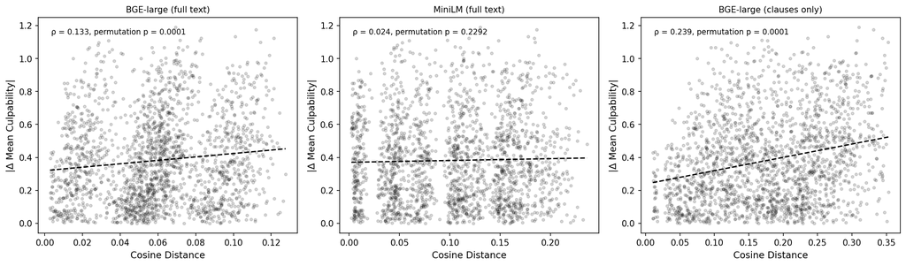

```
Saved: output/nlp/figures/fig_s2_rsa_scatter.pdf
```

```python
# ── RSA scatter plots: all three analyses (Study 2) ──
fig, axes = plt.subplots(1, 3, figsize=(15, 4.5))
for ax, (emb_label, cos_vec), title in zip(axes, EMBEDDINGS.items(),
                                           ['BGE-large (full text)', 'MiniLM (full text)', 'BGE-large (clauses only)']):
    res = rsa_results[("Study 2", emb_label)]
    culp_vec = res["culp_vec"]
    ax.scatter(cos_vec, culp_vec, alpha=0.15, s=10, color='black')
    z = np.polyfit(cos_vec, culp_vec, 1)
    x_line = np.linspace(cos_vec.min(), cos_vec.max(), 100)
    ax.plot(x_line, np.poly1d(z)(x_line), color='black', linewidth=1.5, linestyle='--')
    ax.set_xlabel('Cosine Distance')
    ax.set_ylabel('|Δ Mean Culpability|')
    ax.annotate(f"ρ = {res['rho']:.3f}, permutation p = {res['p_perm']:.4f}",
                xy=(0.05, 0.95), xycoords='axes fraction', fontsize=9, va='top')
    ax.set_title(title, fontsize=10)
plt.tight_layout()
save_fig('fig_s2_rsa_scatter.pdf')
```

The single-feature embedding distances below depend only on the vignette texts and the embedding models, so they are the same for both studies; they are recomputed as a check that the embeddings reproduce Study 1's. In Study 1 they were, for BGE-large: location .0443, contents .0380, source .0127, payment .0117, package .0079 and inquiry .0042. The Study 1 figure (`fig_embedding_feature_distances.pdf`) applies to Study 2 unchanged.

```python
# ── Feature-specific embedding distances (the same for both studies) ──
# For each binary feature, the mean cosine distance between vignettes that differ only on that feature.
cos_mat_bge = squareform(EMBEDDINGS["BGE-large (full text)"])
cos_mat_mini = squareform(EMBEDDINGS["MiniLM (full text)"])
B_ = vignette_stats[FEATURE_COLS_NO_SLIDER].values
rows = []
for f, label in enumerate(['Source', 'Package', 'Inquiry', 'Payment', 'Location', 'Contents']):
    others = [j for j in range(6) if j != f]
    pairs = [(i, j) for i in range(64) for j in range(i + 1, 64)
             if B_[i, f] != B_[j, f] and (B_[i, others] == B_[j, others]).all()]
    rows.append({'Feature': label,
                 'BGE dist': np.mean([cos_mat_bge[i, j] for i, j in pairs]),
                 'MiniLM dist': np.mean([cos_mat_mini[i, j] for i, j in pairs]),
                 'N pairs': len(pairs)})
fd_df = pd.DataFrame(rows)
for _, r in fd_df.iterrows():
    print(f"  {r['Feature']}: BGE={r['BGE dist']:.4f}, MiniLM={r['MiniLM dist']:.4f} ({r['N pairs']} pairs)")
save_table(fd_df, "embedding_feature_distances.csv")
```

```
  Source: BGE=0.0127, MiniLM=0.0356 (32 pairs)
  Package: BGE=0.0079, MiniLM=0.0069 (32 pairs)
  Inquiry: BGE=0.0042, MiniLM=0.0054 (32 pairs)
  Payment: BGE=0.0117, MiniLM=0.0035 (32 pairs)
  Location: BGE=0.0443, MiniLM=0.0507 (32 pairs)
  Contents: BGE=0.0380, MiniLM=0.1043 (32 pairs)
Saved: output/nlp/embedding_feature_distances.csv
```

## 9. Free-Text Justification Analysis

Each participant wrote a brief justification after each choice. As in Study 1, justifications longer than five characters are embedded with BGE-large and projected with UMAP, colored by the choice. In Study 2 each justification was written after the choice and the belief rating and before the three probe questions.

**Addition.** The Study 2 projection is also colored by the probe-defined category. The Study 1 justifications are embedded too, for the Study 1 rerun of the text classifier in Section 10.

```
Trials with justification text (>5 chars): Study 1 1044 / 1060; Study 2 1307 / 1310
Embedded 1307 Study 2 and 1044 Study 1 justifications with BGE-large in 20 s
```

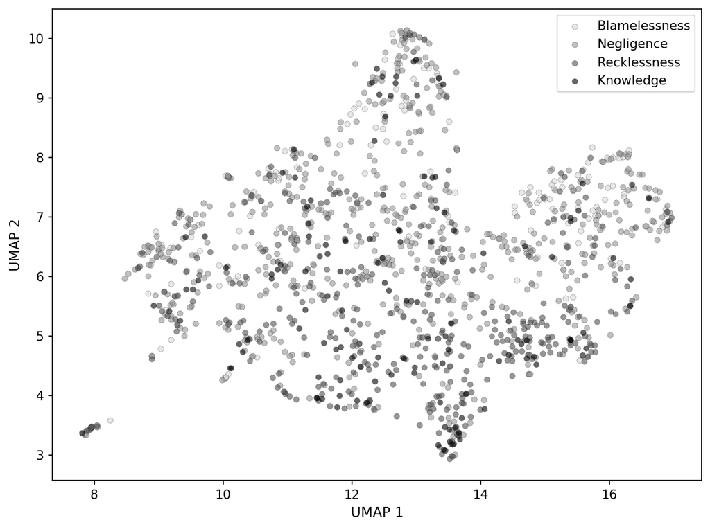

```
Saved: output/nlp/figures/fig_s2_justification_umap.pdf
```

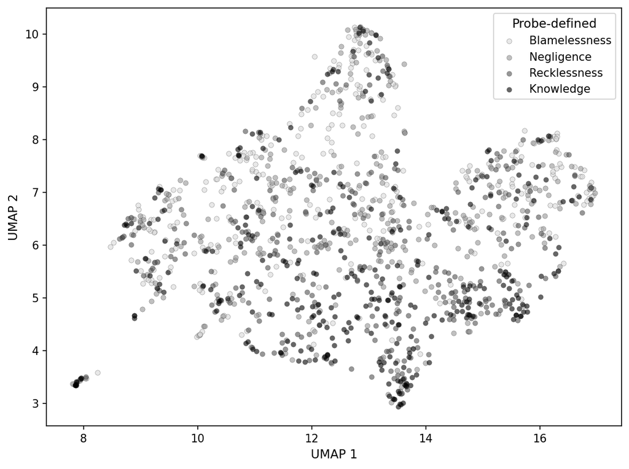

```
Saved: output/nlp/figures/fig_s2_justification_umap_probe.pdf
```

```python
# ── Justification texts (more than five characters, as in Study 1) ──
def with_text(d):
    text = d["justification"].fillna("").astype(str).str.strip()
    return d.assign(justification_clean=text)[text.str.len() > 5].copy()

d1_just, d_just = with_text(d1), with_text(d2)
print(f"Trials with justification text (>5 chars): Study 1 {len(d1_just)} / {len(d1)}; Study 2 {len(d_just)} / {len(d2)}")

# ── Embed justification texts with BGE (primary model) ──
just_texts = d_just["justification_clean"].tolist()
t0 = time.time()
just_embeddings = st_model_bge.encode(just_texts, batch_size=32, normalize_embeddings=True)
just_embeddings_s1 = st_model_bge.encode(d1_just["justification_clean"].tolist(), batch_size=32,
                                         normalize_embeddings=True)
print(f"Embedded {len(just_texts)} Study 2 and {len(d1_just)} Study 1 justifications with BGE-large "
      f"in {time.time() - t0:.0f} s")

# ── UMAP on Study 2 justifications ──
reducer_just = umap.UMAP(n_components=2, n_neighbors=15, min_dist=0.1,
                         metric='cosine', random_state=SEED)
just_umap = reducer_just.fit_transform(just_embeddings)
d_just['just_umap_x'] = just_umap[:, 0]
d_just['just_umap_y'] = just_umap[:, 1]

gray_palette = {'Blamelessness': '#d9d9d9', 'Negligence': '#969696',
                'Recklessness': '#525252', 'Knowledge': '#000000'}

def justification_map(column, legend_title, name):
    fig, ax = plt.subplots(figsize=(8, 6))
    for judgment in JUDGMENT_ORDER:
        subset = d_just[d_just[column] == judgment]
        ax.scatter(subset['just_umap_x'], subset['just_umap_y'],
                   c=gray_palette[judgment], label=judgment,
                   s=20, alpha=0.6, edgecolors='black', linewidth=0.2)
    ax.set_xlabel('UMAP 1')
    ax.set_ylabel('UMAP 2')
    ax.legend(loc='best', title=legend_title)
    plt.tight_layout()
    save_fig(name)

justification_map('judgment', None, 'fig_s2_justification_umap.pdf')
justification_map('probe_judgment', 'Probe-defined', 'fig_s2_justification_umap_probe.pdf')
```

## 10. BERTopic & Text-to-Judgment Classification

BERTopic finds recurring themes in the justifications through sentence embeddings, UMAP, HDBSCAN clustering and class-based TF-IDF, and each justification is assigned to a topic (or to the outlier group, topic −1). As in Study 1, the model is fitted twice, once with the BGE embeddings and once with MiniLM, whose smaller embedding space gives the density-based clustering more structure to work with and in Study 1 yielded far more topics (23, against 3 with BGE). For each topic the notebook prints its size, its eight top keywords and its mix of categories. It does not print the example justifications BERTopic stores for each topic, so that no individual justification appears in the output; the topic tables are saved without them.

The text classifier asks whether a simple model can predict the choice from the justification embedding alone: a logistic regression on the BGE embeddings, with 10-fold cross-validation, as in Study 1 (accuracy .519 ± .037, κ = .237).

**Additions.** The MiniLM topics are also crossed with the probe-defined category and, if `data/processed/justification_codes.csv` is in the folder, with the registered justification codes, which shows what each topic contains in the codebook's terms. The classifier is also run on Study 1 (the rerun) and with the probe-defined category as the outcome, and once more with balanced class weights, so that its recall of Knowledge does not depend on how common Knowledge is.

```
Number of topics discovered: 2 (outliers, topic -1: 0)

════════════════════════════════════════════════════════════
BGE Topic Descriptions (representative keywords)
════════════════════════════════════════════════════════════
  Topic  0 (n=1288, dominant=Negligence 49%): he, the, was, to, it, that, and, not
  Topic  1 (n= 19, dominant=Negligence 42%): on, based, the, judgment, scenario, used, my, made
Saved: output/nlp/topics_bge.csv
```

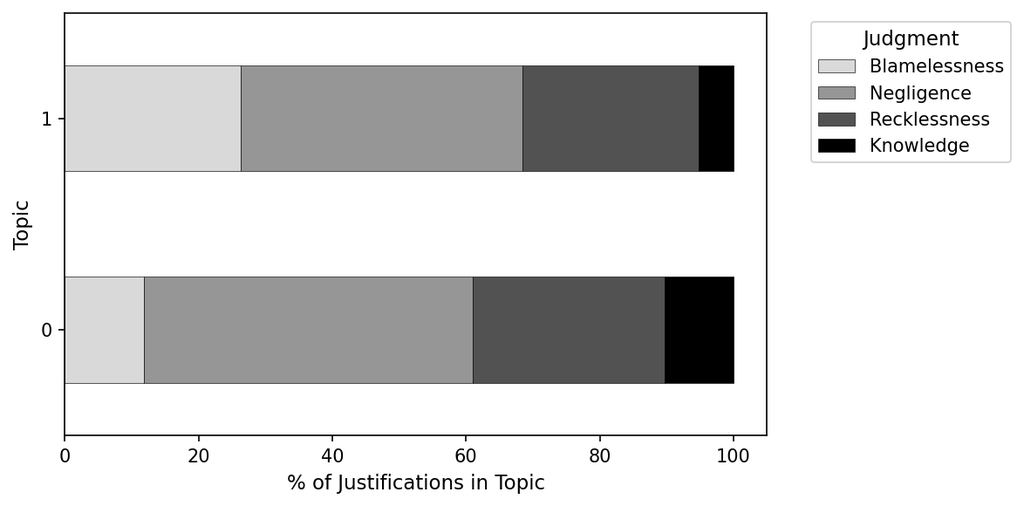

```
Saved: output/nlp/figures/fig_s2_bertopic_judgment.pdf
```

```python
# ── BERTopic on justification texts (BGE) ──
def describe_topics(model, topic_col, judgment_col="judgment"):
    # One row per topic: size, top keywords and category mix. No example texts.
    rows = []
    for topic_id in sorted(t for t in model.get_topics() if t != -1):
        sub = d_just[d_just[topic_col] == topic_id]
        mix = sub[judgment_col].value_counts(normalize=True).reindex(JUDGMENT_ORDER, fill_value=0) * 100
        rows.append({"Topic": topic_id, "n": len(sub),
                     "Keywords": ", ".join(w for w, _ in model.get_topic(topic_id)[:8]),
                     "Dominant": mix.idxmax(), "Dominant %": mix.max(),
                     **{f"{c} %": mix[c] for c in JUDGMENT_ORDER}})
    return pd.DataFrame(rows)

def print_topics(table, label):
    print("═" * 60)
    print(f"{label} Topic Descriptions (representative keywords)")
    print("═" * 60)
    for _, r in table.iterrows():
        print(f"  Topic {r['Topic']:2d} (n={r['n']:3d}, dominant={r['Dominant']} {r['Dominant %']:.0f}%): {r['Keywords']}")

def topic_crosstab(topic_col, judgment_col, legend_title, name):
    crosstab = pd.crosstab(d_just[topic_col], d_just[judgment_col], normalize='index')
    crosstab = crosstab.reindex(columns=JUDGMENT_ORDER, fill_value=0) * 100
    crosstab = crosstab.drop(index=-1, errors='ignore')
    if len(crosstab) > 1:
        fig, ax = plt.subplots(figsize=(8, max(4, len(crosstab) * 0.4)))
        crosstab.plot(kind='barh', stacked=True, ax=ax,
                      color=['#d9d9d9', '#969696', '#525252', '#000000'],
                      edgecolor='black', linewidth=0.3)
        ax.set_xlabel('% of Justifications in Topic')
        ax.set_ylabel('Topic')
        ax.legend(title=legend_title, bbox_to_anchor=(1.05, 1), loc='upper left')
        plt.tight_layout()
        save_fig(name)
    else:
        print("Only one topic found; no crosstab to plot.")

if BERTOPIC_AVAILABLE:
    topic_model = BERTopic(
        embedding_model=st_model_bge,
        umap_model=umap.UMAP(n_components=5, n_neighbors=15, min_dist=0.0,
                             metric='cosine', random_state=SEED),
        nr_topics='auto',
        verbose=False
    )
    topics, probs = topic_model.fit_transform(just_texts, just_embeddings)
    d_just['topic'] = topics
    topics_bge = describe_topics(topic_model, 'topic')
    print(f"Number of topics discovered: {len(topics_bge)} (outliers, topic -1: {(d_just['topic'] == -1).sum()})")
    print()
    print_topics(topics_bge, "BGE")
    save_table(topics_bge, "topics_bge.csv")
    topic_crosstab('topic', 'judgment', 'Judgment', 'fig_s2_bertopic_judgment.pdf')
else:
    print("BERTopic not available. Install with: pip install bertopic")
```

### BERTopic with MiniLM (robustness comparison)

As in Study 1, the topic model is refitted with MiniLM embeddings. BGE-large's 1024-dimensional embeddings concentrate short justifications in a dense region of the space and so give HDBSCAN few clusters; the smaller MiniLM space usually separates more themes. This reflects how embedding geometry interacts with density-based clustering, not a weakness of BGE for the RSA or the classifier.

```
MiniLM topics discovered: 27 (vs. 2 with BGE); outliers: 201

════════════════════════════════════════════════════════════
MiniLM Topic Descriptions (representative keywords)
════════════════════════════════════════════════════════════
  Topic  0 (n=161, dominant=Negligence 47%): package, he, the, to, it, was, from, what
  Topic  1 (n=137, dominant=Negligence 56%): coffee, it, he, was, just, to, told, that
  Topic  2 (n= 83, dominant=Recklessness 39%): david, was, the, that, and, he, it, his
  Topic  3 (n= 66, dominant=Negligence 47%): biker, the, he, to, know, have, would, random
  Topic  4 (n= 58, dominant=Negligence 41%): coffee, robert, andrew, told, was, it, and, the
  Topic  5 (n= 56, dominant=Negligence 62%): daniel, that, in, package, the, to, not, was
  Topic  6 (n= 49, dominant=Negligence 51%): robert, the, was, his, with, to, what, in
  Topic  7 (n= 47, dominant=Negligence 55%): uncle, his, trusted, he, family, relative, him, was
  Topic  8 (n= 46, dominant=Negligence 57%): john, the, package, have, that, was, to, his
  Topic  9 (n= 44, dominant=Negligence 57%): bag, the, he, in, for, checked, have, not
  Topic 10 (n= 34, dominant=Negligence 59%): andrew, the, package, his, to, uncle, and, of
  Topic 11 (n= 32, dominant=Negligence 53%): drugs, drug, if, he, it, knew, don, think
  Topic 12 (n= 29, dominant=Negligence 48%): daniel, coffee, it, was, so, and, the, that
  Topic 13 (n= 27, dominant=Recklessness 33%): money, financially, he, gain, compensation, payment, any, risk
  Topic 14 (n= 26, dominant=Blamelessness 46%): fentanyl, contained, failure, it, was, coffee, his, that
  Topic 15 (n= 26, dominant=Recklessness 38%): john, coffee, contained, was, it, told, material, than
  Topic 16 (n= 23, dominant=Negligence 65%): biker, coffee, the, andrew, border, across, and, from
  Topic 17 (n= 19, dominant=Negligence 42%): based, judgment, scenario, on, used, information, my, made
  Topic 18 (n= 19, dominant=Recklessness 47%): checked, check, should, he, have, checking, content, but
  Topic 19 (n= 19, dominant=Negligence 37%): 1000, illicit, knew, he, context, there, something, likely
  Topic 20 (n= 18, dominant=Recklessness 67%): bag, duffel, amount, to, is, the, 1000, across
  Topic 21 (n= 18, dominant=Negligence 67%): he, but, know, not, aware, should, did, knew
  Topic 22 (n= 18, dominant=Negligence 78%): andrew, trusted, true, his, enough, easily, possible, uncle
  Topic 23 (n= 15, dominant=Negligence 67%): stranger, should, this, especially, very, he, do, trusted
  Topic 24 (n= 13, dominant=Negligence 62%): doing, wrong, friend, capacity, favor, think, thought, mental
  Topic 25 (n= 12, dominant=Negligence 75%): drugs, family, your, if, uncle, is, smart, trusted
  Topic 26 (n= 11, dominant=Recklessness 73%): red, flag, flags, being, obvious, offered, 1000, thousand
Saved: output/nlp/topics_minilm.csv
```

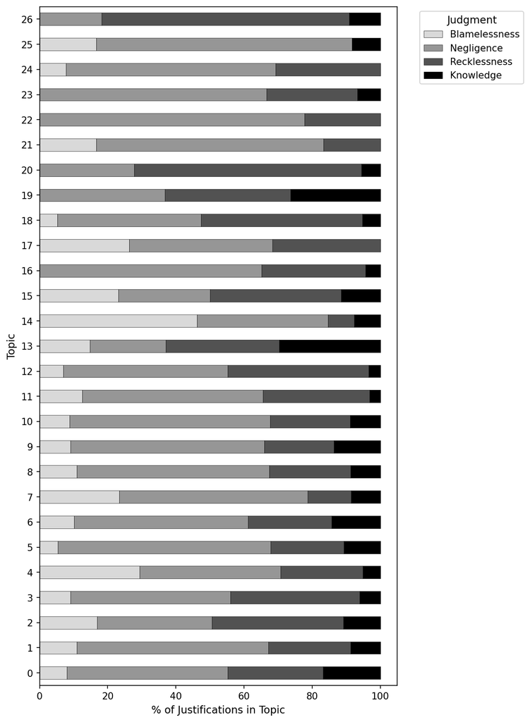

```
Saved: output/nlp/figures/fig_s2_bertopic_judgment_minilm.pdf
```

```python
# ── BERTopic with MiniLM (for richer topic discovery) ──
if BERTOPIC_AVAILABLE:
    just_embeddings_mini = st_model_mini.encode(just_texts, batch_size=32, normalize_embeddings=True)
    topic_model_mini = BERTopic(
        embedding_model=st_model_mini,
        umap_model=umap.UMAP(n_components=5, n_neighbors=15, min_dist=0.0,
                             metric='cosine', random_state=SEED),
        nr_topics='auto',
        verbose=False
    )
    topics_mini, probs_mini = topic_model_mini.fit_transform(just_texts, just_embeddings_mini)
    d_just['topic_mini'] = topics_mini
    topics_minilm = describe_topics(topic_model_mini, 'topic_mini')
    print(f"MiniLM topics discovered: {len(topics_minilm)} (vs. {len(topics_bge)} with BGE); "
          f"outliers: {(d_just['topic_mini'] == -1).sum()}")
    print()
    print_topics(topics_minilm, "MiniLM")
    save_table(topics_minilm, "topics_minilm.csv")
    topic_crosstab('topic_mini', 'judgment', 'Judgment', 'fig_s2_bertopic_judgment_minilm.pdf')
else:
    print("Skipped: BERTopic not available.")
```

```
MiniLM topics by probe-defined category (% of each topic):
 Topic   n      Dominant  Dominant %  Blamelessness %  Negligence %  Recklessness %  Knowledge %
     0 161    Negligence        30.0             28.0          30.0            15.0         27.0
     1 137     Knowledge        28.0             28.0          28.0            16.0         28.0
     2  83    Negligence        31.0             27.0          31.0            25.0         17.0
     3  66    Negligence        35.0             18.0          35.0            24.0         23.0
     4  58 Blamelessness        33.0             33.0          19.0            28.0         21.0
     5  56 Blamelessness        34.0             34.0          29.0            20.0         18.0
     6  49 Blamelessness        29.0             29.0          29.0            22.0         20.0
     7  47    Negligence        36.0             34.0          36.0             6.0         23.0
     8  46  Recklessness        30.0             28.0          17.0            30.0         24.0
     9  44 Blamelessness        34.0             34.0          27.0            14.0         25.0
    10  34    Negligence        44.0             18.0          44.0            32.0          6.0
    11  32     Knowledge        34.0             19.0          28.0            19.0         34.0
    12  29  Recklessness        41.0              7.0          24.0            41.0         28.0
    13  27     Knowledge        33.0             19.0          22.0            26.0         33.0
    14  26     Knowledge        31.0             27.0          23.0            19.0         31.0
    15  26 Blamelessness        27.0             27.0          23.0            27.0         23.0
    16  23    Negligence        35.0              9.0          35.0            35.0         22.0
    17  19     Knowledge        53.0             16.0          16.0            16.0         53.0
    18  19     Knowledge        42.0             16.0          32.0            11.0         42.0
    19  19     Knowledge        53.0              0.0          21.0            26.0         53.0
    20  18     Knowledge        44.0             11.0          11.0            33.0         44.0
    21  18    Negligence        33.0             28.0          33.0            17.0         22.0
    22  18 Blamelessness        33.0             33.0          17.0            28.0         22.0
    23  15    Negligence        53.0             13.0          53.0            13.0         20.0
    24  13    Negligence        54.0             31.0          54.0            15.0          0.0
    25  12    Negligence        42.0             33.0          42.0             8.0         17.0
    26  11  Recklessness        55.0              0.0          18.0            55.0         27.0
Saved: output/nlp/topics_minilm_probe.csv
```

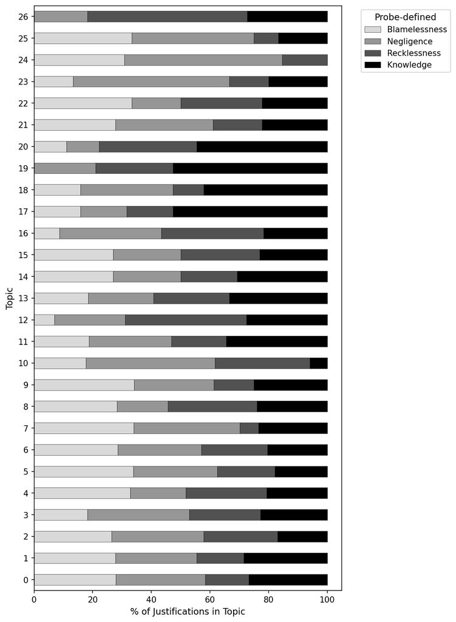

```
Saved: output/nlp/figures/fig_s2_bertopic_probe_minilm.pdf

MiniLM topics by justification code (% of each topic; topic -1 holds the outliers):
code          n  Knew  Suspected  Unaware, at fault  Unaware, no fault  Act or situation only  Evidentiary  Uncodable
topic_mini
-1          201   8.0       25.0               39.0               14.0                    6.0          2.0        5.0
 0          161   7.0       25.0               42.0               19.0                    6.0          0.0        1.0
 1          137  19.0       22.0               26.0               31.0                    1.0          1.0        0.0
 2           83  10.0       28.0               36.0               25.0                    0.0          1.0        0.0
 3           66   6.0       27.0               41.0               21.0                    5.0          0.0        0.0
 4           58   9.0       17.0               28.0               43.0                    0.0          3.0        0.0
 5           56   5.0       12.0               43.0               29.0                    0.0          5.0        5.0
 6           49   6.0       18.0               43.0               29.0                    0.0          4.0        0.0
 7           47   2.0       11.0               19.0               62.0                    2.0          0.0        4.0
 8           46   4.0       17.0               46.0               24.0                    7.0          2.0        0.0
```

[output cut: 19 more lines]

```python
# ── Addition: MiniLM topics by probe-defined category, and by justification code ──
if BERTOPIC_AVAILABLE:
    probe_mix = describe_topics(topic_model_mini, 'topic_mini', 'probe_judgment')
    print("MiniLM topics by probe-defined category (% of each topic):")
    print(probe_mix.drop(columns=["Keywords"]).round(0).to_string(index=False))
    save_table(probe_mix, "topics_minilm_probe.csv")
    topic_crosstab('topic_mini', 'probe_judgment', 'Probe-defined', 'fig_s2_bertopic_probe_minilm.pdf')

    CODES_FILE = "data/processed/justification_codes.csv"
    if os.path.exists(CODES_FILE):
        codes = pd.read_csv(CODES_FILE, dtype={"participant": str})
        codes = codes[codes["study"] == 2][["participant", "vignette_position", "code"]]
        merged = d_just.merge(codes, left_on=["pid", "position"], right_on=["participant", "vignette_position"],
                              how="left", validate="one_to_one")
        assert merged["code"].notna().all(), "every Study 2 justification should have a code"
        CODE_ORDER = ["Knew", "Suspected", "Unaware, at fault", "Unaware, no fault",
                      "Act or situation only", "Evidentiary", "Uncodable"]
        by_code = (pd.crosstab(merged["topic_mini"], merged["code"], normalize="index")
                   .reindex(columns=CODE_ORDER, fill_value=0) * 100)
        by_code.insert(0, "n", merged["topic_mini"].value_counts().reindex(by_code.index))
        print()
        print("MiniLM topics by justification code (% of each topic; topic -1 holds the outliers):")
        print(by_code.round(0).to_string())
        save_table(by_code.reset_index(names="Topic"), "topics_minilm_codes.csv")
    else:
        print(f"{CODES_FILE} is not in the folder; the table of topics by justification code is skipped.")
```

```
Text-only classification (BGE embeddings, 10-fold CV), Study 2:
  Accuracy: 0.591 ± 0.036
  Cohen's κ: 0.283
  Chance level: 0.250 (uniform) or 0.490 (majority class)

               precision    recall  f1-score   support

Blamelessness       0.62      0.13      0.22       158
   Negligence       0.59      0.87      0.70       641
 Recklessness       0.59      0.51      0.55       375
    Knowledge       0.00      0.00      0.00       133

     accuracy                           0.59      1307
    macro avg       0.45      0.38      0.37      1307
 weighted avg       0.53      0.59      0.53      1307

              Outcome  Justifications  Accuracy    SD  Kappa  Majority rate  Knowledge recall
              Study 1            1044     0.519 0.037  0.237          0.429             0.021
              Study 2            1307     0.591 0.036  0.283          0.490             0.000
Study 2 probe-defined            1307     0.445 0.041  0.253          0.282             0.474
Study 1 notebook: accuracy 0.519 ± 0.037, κ = 0.237, Knowledge recall 0.02.
Saved: output/nlp/text_classification.csv

Balanced class weights:
              Outcome  Accuracy    SD  Kappa  Blamelessness recall  Negligence recall  Recklessness recall  Knowledge recall
              Study 1     0.459 0.033  0.260                 0.602              0.435                0.502             0.270
              Study 2     0.469 0.047  0.267                 0.722              0.420                0.507             0.301
Study 2 probe-defined     0.432 0.057  0.240                 0.603              0.353                0.335             0.431
Saved: output/nlp/text_classification_balanced.csv
```

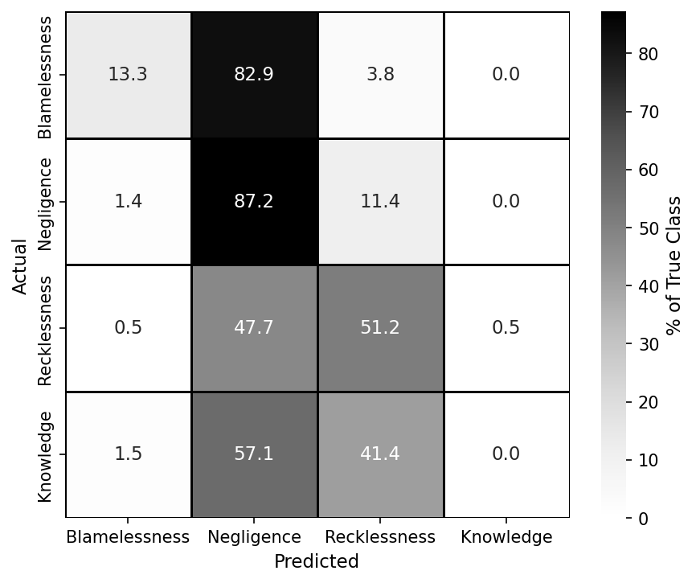

```
Saved: output/nlp/figures/fig_s2_text_classification_cm.pdf
```

```python
# ── Text-to-judgment classification ──
# Can the justification embedding alone predict the mental state judgment?
def text_classifier(embeddings, y_text):
    lr = LogisticRegression(max_iter=1000, C=1.0, random_state=SEED, n_jobs=-1)
    return cv_evaluate(lr, embeddings, y_text)

TEXT_OUTCOMES = {"Study 1": (just_embeddings_s1, d1_just["culpability"].values),
                 "Study 2": (just_embeddings, d_just["culpability"].values),
                 "Study 2 probe-defined": (just_embeddings, d_just["probe_culpability"].values)}
text_res = {label: text_classifier(emb, y_text) for label, (emb, y_text) in TEXT_OUTCOMES.items()}

y_text = d_just["culpability"].values
r = text_res["Study 2"]
print("Text-only classification (BGE embeddings, 10-fold CV), Study 2:")
print(f"  Accuracy: {r['acc']:.3f} ± {r['sd']:.3f}")
print(f"  Cohen's κ: {r['kappa']:.3f}")
print(f"  Chance level: {1/4:.3f} (uniform) or "
      f"{pd.Series(y_text).value_counts(normalize=True).max():.3f} (majority class)")
print()
print(classification_report(y_text, r["pred"], target_names=JUDGMENT_ORDER))

rows = []
for label, res in text_res.items():
    y_out = TEXT_OUTCOMES[label][1]
    rows.append({"Outcome": label, "Justifications": len(y_out), "Accuracy": res["acc"], "SD": res["sd"],
                 "Kappa": res["kappa"], "Majority rate": pd.Series(y_out).value_counts(normalize=True).max(),
                 "Knowledge recall": np.mean(res["pred"][y_out == 4] == 4)})
text_table = pd.DataFrame(rows)
print(text_table.round(3).to_string(index=False))
print("Study 1 notebook: accuracy 0.519 ± 0.037, κ = 0.237, Knowledge recall 0.02.")
save_table(text_table, "text_classification.csv")

# ── Addition: the same classifier with balanced class weights ──
# Without class weights a logistic regression rarely predicts a small category, so the recall of
# Knowledge depends on how common Knowledge is (about 10% of choices but 25% of probe-defined
# categories in Study 2). Balanced weights put the categories on an equal footing.
rows = []
for label, (emb, y_out) in TEXT_OUTCOMES.items():
    lr_bal = LogisticRegression(max_iter=1000, C=1.0, class_weight='balanced', random_state=SEED, n_jobs=-1)
    res = cv_evaluate(lr_bal, emb, y_out)
    recall = {f"{c} recall": np.mean(res["pred"][y_out == k + 1] == k + 1) for k, c in enumerate(JUDGMENT_ORDER)}
    rows.append({"Outcome": label, "Accuracy": res["acc"], "SD": res["sd"], "Kappa": res["kappa"], **recall})
text_balanced = pd.DataFrame(rows)
print()
print("Balanced class weights:")
print(text_balanced.round(3).to_string(index=False))
save_table(text_balanced, "text_classification_balanced.csv")

# ── Confusion matrix (Study 2) ──
cm_text = confusion_matrix(y_text, r["pred"])
cm_text_pct = cm_text.astype(float) / cm_text.sum(axis=1, keepdims=True) * 100
fig, ax = plt.subplots(figsize=(6, 5))
sns.heatmap(cm_text_pct, annot=True, fmt='.1f', cmap='Greys',
            xticklabels=JUDGMENT_ORDER, yticklabels=JUDGMENT_ORDER,
            cbar_kws={'label': '% of True Class'}, linewidths=0.5,
            linecolor='black', ax=ax)
ax.set_xlabel('Predicted')
ax.set_ylabel('Actual')
plt.tight_layout()
save_fig('fig_s2_text_classification_cm.pdf')
```

## 11. Combined Feature + Text Model

As in Study 1, we test whether adding the justification embedding to the feature-based model improves classification, which tells us whether participants' written reasoning carries information about their choice beyond what the vignette features and the belief rating capture. All models are fitted to the trials with a justification, with the same folds. In Study 1 the combined model (features and text, .531 ± .042) outperformed both the features alone (.315 ± .051; t = 13.99, p < .001) and the features with the belief rating (.470 ± .062; t = 3.83, p = .004). The comparison runs on Study 2 and on Study 1 (the rerun).

Embeddings computed on a CPU and on a GPU differ in their last digits. The logistic regression above is not affected, but a forest that splits on the 1,024 embedding dimensions can be, so without a GPU the combined model's Study 1 numbers can differ slightly from the published ones (a CPU test run gave .531 ± .041, t = 14.46 and t = 3.69).

```python
# ── Combined: features + text embedding ──
def combined_models(dj, embeddings, text_result):
    y_c = dj["culpability"].values
    feat = cv_evaluate(RandomForestClassifier(**RF_PARAMS), dj[FEATURE_COLS_NO_SLIDER].values, y_c)
    full = cv_evaluate(RandomForestClassifier(**RF_PARAMS), dj[FEATURE_COLS].values, y_c)
    comb = cv_evaluate(RandomForestClassifier(**RF_PARAMS),
                       np.hstack([dj[FEATURE_COLS_NO_SLIDER].values, embeddings]), y_c)
    return {"Features only (6 binary)": feat, "Features + belief rating (7)": full,
            "Text embedding only (BGE)": text_result, "Features + text (6 + BGE)": comb}

combined, rows = {}, []
for label, dj, emb in [("Study 2", d_just, just_embeddings), ("Study 1", d1_just, just_embeddings_s1)]:
    t0 = time.time()
    res = combined_models(dj, emb, text_res[label])
    combined[label] = res
    print("═" * 60)
    print(f"Model Comparison (10-fold CV accuracy, justification subset), {label}")
    print("═" * 60)
    for name, r in res.items():
        print(f"  {name:<28} {r['acc']:.3f} ± {r['sd']:.3f}")
        rows.append({"Study": label, "Model": name, "Accuracy": r["acc"], "SD": r["sd"], "Kappa": r["kappa"]})
    comb = res["Features + text (6 + BGE)"]["folds"]
    t1, p1 = stats.ttest_rel(comb, res["Features only (6 binary)"]["folds"])
    t2, p2 = stats.ttest_rel(comb, res["Features + belief rating (7)"]["folds"])
    print()
    print(f"  Combined vs features-only:      t = {t1:.2f}, p = {p1:.4f}")
    print(f"  Combined vs features + belief:  t = {t2:.2f}, p = {p2:.4f}")
    print(f"  ({time.time() - t0:.0f} s)")
    print()
    rows.append({"Study": label, "Model": "t: combined vs features only", "Accuracy": t1, "SD": p1, "Kappa": np.nan})
    rows.append({"Study": label, "Model": "t: combined vs features + belief", "Accuracy": t2, "SD": p2, "Kappa": np.nan})
combined_table = pd.DataFrame(rows)
print("Study 1 notebook: features .315 ± .051, features + slider .470 ± .062, text .519 ± .037, "
      "features + text .531 ± .042; t = 13.99 (p < .0001) and t = 3.83 (p = .0040).")
print("In the saved table, the rows starting with t hold the t statistic under Accuracy and its p value under SD.")
save_table(combined_table, "combined_models.csv")
```

```
════════════════════════════════════════════════════════════
Model Comparison (10-fold CV accuracy, justification subset), Study 2
════════════════════════════════════════════════════════════
  Features only (6 binary)     0.387 ± 0.043
  Features + belief rating (7) 0.466 ± 0.034
  Text embedding only (BGE)    0.591 ± 0.036
  Features + text (6 + BGE)    0.602 ± 0.038

  Combined vs features-only:      t = 12.18, p = 0.0000
  Combined vs features + belief:  t = 7.55, p = 0.0000
  (54 s)

════════════════════════════════════════════════════════════
Model Comparison (10-fold CV accuracy, justification subset), Study 1
════════════════════════════════════════════════════════════
  Features only (6 binary)     0.315 ± 0.051
  Features + belief rating (7) 0.470 ± 0.062
  Text embedding only (BGE)    0.519 ± 0.037
  Features + text (6 + BGE)    0.531 ± 0.042

  Combined vs features-only:      t = 13.99, p = 0.0000
  Combined vs features + belief:  t = 3.83, p = 0.0040
  (47 s)

Study 1 notebook: features .315 ± .051, features + slider .470 ± .062, text .519 ± .037, features + text .531 ± .042; t = 13.99 (p < .0001) and t = 3.83 (p = .0040).
In the saved table, the rows starting with t hold the t statistic under Accuracy and its p value under SD.
Saved: output/nlp/combined_models.csv
```

## 12. Replication Summary

**Addition.** The table sets each published Study 1 number (from the Study 1 notebook and the submitted manuscript) beside the same quantity recomputed here from the Study 1 data and its Study 2 counterparts. The rerun column should match the published column; the Study 2 columns are the replication. The table is saved as `output/nlp/replication_summary.csv` for the combined report.

```python
# ── Replication summary ──
def apa(x, d=3):
    # A number in APA style: no leading zero for values that cannot exceed 1.
    s = f"{x:.{d}f}"
    return s.replace("0.", ".", 1) if abs(x) < 1 else s

def p_eq(p):
    return "p < .0001" if p < 0.0001 else f"p = {apa(p, 4)}"

def acc(r):
    return f"{apa(r['acc'])} ± {apa(r['sd'])} (κ = {apa(r['kappa'])})"

def ttest_text(res, a, b):
    t, p = stats.ttest_rel(res[a]["folds"], res[b]["folds"])
    return f"t(9) = {t:.2f}, {p_eq(p)}"

def top_text(label, cls):
    s = importance[label][cls].sort_values(ascending=False)
    return f"{s.index[0].split(' (')[0]} {apa(s.iloc[0])} ({s.index[1].split(' (')[0]} {apa(s.iloc[1])})"

def knowledge_text(label):
    r = knowledge_boot.set_index("Outcome").loc[label]
    return (f"{apa(r['Contents |SHAP|'])} vs {apa(r['Payment |SHAP|'])}; contents ahead in "
            f"{r['Contents > payment (% of resamples)']:.0f}% of resamples")

def rate_text(label, feature):
    r = knowledge_rates.set_index(["Outcome", "Feature"]).loc[(label, feature)]
    return (f"{r['Knowledge % (level 1)']:.1f}% vs {r['Knowledge % (level 0)']:.1f}% "
            f"({r['Difference (points)']:+.1f} points)")

def rsa_text(outcome, emb):
    r = rsa_results[(outcome, emb)]
    return f"ρ = {apa(r['rho'])} (pairs {p_eq(r['p_pairs'])}; permutation {p_eq(r['p_perm'])})"

def balanced_text(label):
    r = text_balanced.set_index("Outcome").loc[label]
    return f"{apa(r['Accuracy'])} (κ = {apa(r['Kappa'])}); Knowledge recall {apa(r['Knowledge recall'], 2)}"

def combined_text(label, other):
    res = combined[label]
    t, p = stats.ttest_rel(res["Features + text (6 + BGE)"]["folds"], res[other]["folds"])
    return f"{apa(res['Features + text (6 + BGE)']['acc'])} vs {apa(res[other]['acc'])}; t = {t:.2f}, {p_eq(p)}"

O = ["Study 1", "Study 2", "Study 2 probe-defined"]
summary = [
    ("RF, features only", ".307 ± .035 (κ = .074)", *[acc(rf_res[o]["A"]) for o in O]),
    ("RF, belief rating only", ".399 ± .035 (κ = .189)", *[acc(rf_res[o]["C"]) for o in O]),
    ("RF, features + belief rating", ".473 ± .029 (κ = .254)", *[acc(rf_res[o]["B"]) for o in O]),
    ("RF, features vs features + belief", "t(9) = -11.15, p < .0001", *[ttest_text(rf_res[o], "A", "B") for o in O]),
    ("SHAP first (second), Blamelessness", "Source .115 (Payment .070)", *[top_text(o, "Blamelessness") for o in O]),
    ("SHAP first (second), Negligence", "Payment .057", *[top_text(o, "Negligence") for o in O]),
    ("SHAP first (second), Recklessness", "Payment .088", *[top_text(o, "Recklessness") for o in O]),
    ("SHAP first (second), Knowledge", "Contents .049 (Payment .042)", *[top_text(o, "Knowledge") for o in O]),
    ("Knowledge: contents vs payment |SHAP|", ".049 vs .042", *[knowledge_text(o) for o in O]),
    ("Knowledge %, fentanyl vs rare-disease drugs", "not reported", *[rate_text(o, "Contents (fentanyl)") for o in O]),
    ("Knowledge %, $1,000 vs no payment", "not reported", *[rate_text(o, "Payment ($1000)") for o in O]),
    ("RSA, BGE-large full text", "ρ = .077 (pairs p = .0006)", *[rsa_text(o, "BGE-large (full text)") for o in O]),
    ("RSA, MiniLM full text", "ρ = .019 (pairs p = .3949)", *[rsa_text(o, "MiniLM (full text)") for o in O]),
    ("RSA, BGE-large clauses only", "ρ = .129 (pairs p < .0001)", *[rsa_text(o, "BGE-large (clauses only)") for o in O]),
    ("Text classifier (BGE + logistic regression)", ".519 ± .037 (κ = .237)", *[acc(text_res[o]) for o in O]),
    ("Text classifier, balanced class weights", "not run", *[balanced_text(o) for o in O]),
    ("Features + text vs features only", ".531 vs .315; t = 13.99, p < .0001",
     combined_text("Study 1", "Features only (6 binary)"), combined_text("Study 2", "Features only (6 binary)"), "not run"),
    ("Features + text vs features + belief", ".531 vs .470; t = 3.83, p = .0040",
     combined_text("Study 1", "Features + belief rating (7)"), combined_text("Study 2", "Features + belief rating (7)"), "not run"),
    ("BERTopic topics, BGE / MiniLM", "3 / 23", "not run",
     f"{len(topics_bge)} / {len(topics_minilm)}" if BERTOPIC_AVAILABLE else "not run", "same topics as Study 2"),
]
replication = pd.DataFrame(summary, columns=["Analysis", "Study 1 (published)", "Study 1 (rerun here)",
                                             "Study 2", "Study 2 (probe-defined)"])
with pd.option_context("display.max_colwidth", 80, "display.width", 250):
    print(replication.to_string(index=False))
save_table(replication, "replication_summary.csv")
```

```
                                   Analysis                Study 1 (published)                              Study 1 (rerun here)                                           Study 2                           Study 2 (probe-defined)
                          RF, features only             .307 ± .035 (κ = .074)                            .307 ± .035 (κ = .074)                            .395 ± .028 (κ = .176)                            .327 ± .021 (κ = .101)
                     RF, belief rating only             .399 ± .035 (κ = .189)                            .399 ± .035 (κ = .189)                            .363 ± .029 (κ = .154)                            .356 ± .037 (κ = .143)
               RF, features + belief rating             .473 ± .029 (κ = .254)                            .473 ± .029 (κ = .254)                            .481 ± .048 (κ = .248)                            .416 ± .046 (κ = .220)
          RF, features vs features + belief           t(9) = -11.15, p < .0001                          t(9) = -11.15, p < .0001                           t(9) = -6.75, p < .0001                           t(9) = -5.29, p = .0005
         SHAP first (second), Blamelessness         Source .115 (Payment .070)                        Source .115 (Payment .070)                        Payment .111 (Source .094)                        Payment .105 (Source .078)
            SHAP first (second), Negligence                       Payment .057                        Payment .057 (Source .047)                        Payment .078 (Source .030)                        Payment .061 (Source .025)
          SHAP first (second), Recklessness                       Payment .088                        Payment .088 (Source .070)                        Payment .126 (Source .073)                        Payment .077 (Source .035)
             SHAP first (second), Knowledge       Contents .049 (Payment .042)                      Contents .049 (Payment .042)                       Payment .063 (Inquiry .037)                        Payment .089 (Source .025)
      Knowledge: contents vs payment |SHAP|                       .049 vs .042  .049 vs .042; contents ahead in 69% of resamples   .033 vs .063; contents ahead in 8% of resamples   .020 vs .089; contents ahead in 0% of resamples
Knowledge %, fentanyl vs rare-disease drugs                       not reported                      10.7% vs 16.7% (-6.0 points)                       8.8% vs 11.5% (-2.8 points)                      25.7% vs 24.0% (+1.7 points)
          Knowledge %, $1,000 vs no payment                       not reported                      16.0% vs 11.3% (+4.7 points)                       13.0% vs 7.0% (+6.0 points)                     33.9% vs 14.9% (+19.1 points)
                   RSA, BGE-large full text         ρ = .077 (pairs p = .0006) ρ = .077 (pairs p = .0006; permutation p = .0046) ρ = .133 (pairs p < .0001; permutation p < .0001) ρ = .109 (pairs p < .0001; permutation p = .0008)
                      RSA, MiniLM full text         ρ = .019 (pairs p = .3949) ρ = .019 (pairs p = .3949; permutation p = .3490) ρ = .024 (pairs p = .2897; permutation p = .2292) ρ = .021 (pairs p = .3380; permutation p = .2783)
                RSA, BGE-large clauses only         ρ = .129 (pairs p < .0001) ρ = .129 (pairs p < .0001; permutation p = .0002) ρ = .239 (pairs p < .0001; permutation p < .0001) ρ = .193 (pairs p < .0001; permutation p < .0001)
Text classifier (BGE + logistic regression)             .519 ± .037 (κ = .237)                            .519 ± .037 (κ = .237)                            .591 ± .036 (κ = .283)                            .445 ± .041 (κ = .253)
    Text classifier, balanced class weights                            not run             .459 (κ = .260); Knowledge recall .27             .469 (κ = .267); Knowledge recall .30             .432 (κ = .240); Knowledge recall .43
           Features + text vs features only .531 vs .315; t = 13.99, p < .0001                .531 vs .315; t = 13.99, p < .0001                .602 vs .387; t = 12.18, p < .0001                                           not run
       Features + text vs features + belief  .531 vs .470; t = 3.83, p = .0040                 .531 vs .470; t = 3.83, p = .0040                 .602 vs .466; t = 7.55, p < .0001                                           not run
              BERTopic topics, BGE / MiniLM                             3 / 23                                           not run                                            2 / 27                            same topics as Study 2
Saved: output/nlp/replication_summary.csv
```

## 13. Summary of Generated Figures

All figures are saved as PDFs in `output/nlp/figures`: grayscale throughout except the SHAP beeswarm and dependence plots, which keep SHAP's colors as in Study 1, and without titles, which go in the manuscript's captions. Because the folder is in Google Drive, nothing needs to be copied there.

```python
# ── List all generated figures and tables ──
pdfs = sorted(glob.glob(os.path.join(FIG_DIR, 'fig_*.pdf')))
print(f"Generated {len(pdfs)} figures:")
for f in pdfs:
    print(f"  {os.path.basename(f)} ({os.path.getsize(f) / 1024:.0f} KB)")
csvs = sorted(glob.glob(os.path.join(OUT_DIR, '*.csv')))
print(f"\nSaved {len(csvs)} tables in {OUT_DIR}:")
for f in csvs:
    print(f"  {os.path.basename(f)}")
```

```
Generated 21 figures:
  fig_s2_bertopic_judgment.pdf (13 KB)
  fig_s2_bertopic_judgment_minilm.pdf (17 KB)
  fig_s2_bertopic_probe_minilm.pdf (18 KB)
  fig_s2_justification_umap.pdf (36 KB)
  fig_s2_justification_umap_probe.pdf (38 KB)
  fig_s2_rf_confusion_matrix.pdf (21 KB)
  fig_s2_rsa_scatter.pdf (91 KB)
  fig_s2_shap_bar_global.pdf (20 KB)
  fig_s2_shap_blamelessness.pdf (101 KB)
  fig_s2_shap_class_heatmap.pdf (20 KB)
  fig_s2_shap_class_heatmap_comparison.pdf (23 KB)
  fig_s2_shap_dependence.pdf (55 KB)
  fig_s2_shap_importance_bar.pdf (15 KB)
  fig_s2_shap_interactions.pdf (19 KB)
  fig_s2_shap_knowledge.pdf (132 KB)
  fig_s2_shap_knowledge_bootstrap.pdf (20 KB)
  fig_s2_shap_negligence.pdf (104 KB)
  fig_s2_shap_recklessness.pdf (88 KB)
  fig_s2_text_classification_cm.pdf (17 KB)
  fig_s2_umap_vignette_space.pdf (39 KB)
  fig_s2_vignette_means_s1_vs_s2.pdf (17 KB)

Saved 20 tables in output/nlp:
  combined_models.csv
  embedding_feature_distances.csv
  knowledge_rates_by_feature.csv
  replication_summary.csv
  rf_cv_accuracy.csv
  rf_paired_tests.csv
  rsa.csv
  shap_bootstrap.csv
  shap_bootstrap_knowledge.csv
  shap_bootstrap_rank_first.csv
  shap_class_importance.csv
  shap_top_features.csv
  text_classification.csv
  text_classification_balanced.csv
  topics_bge.csv
  topics_minilm.csv
  topics_minilm_codes.csv
  topics_minilm_probe.csv
  vignette_means.csv
  vignette_means_correlations.csv
```

```python
# ── Session info ──
info = {
    "Python": platform.python_version(), "NumPy": np.__version__, "Pandas": pd.__version__,
    "Scikit-learn": sklearn.__version__, "SHAP": shap.__version__,
    "Sentence-Transformers": sentence_transformers.__version__, "UMAP": installed("umap-learn"),
    "BERTopic": installed("bertopic"), "HDBSCAN": installed("hdbscan"),
    "Torch": torch.__version__, "Transformers": transformers.__version__,
    "GPU": torch.cuda.get_device_name(0) if torch.cuda.is_available() else "none",
    "BGE model": f"{BGE_MODEL} @ {BGE_REVISION}", "MiniLM model": f"{MINI_MODEL} @ {MINI_REVISION}",
    "Seed": SEED, "Sample": SAMPLE, "Bootstrap resamples": N_BOOT, "Permutations": N_PERM}
for k, v in info.items():
    print(f"{k}: {v}")
with open(os.path.join(OUT_DIR, "session_info.txt"), "w", encoding="utf-8") as fh:
    fh.write("\n".join(f"{k}: {v}" for k, v in info.items()) + "\n")
```

```
Python: 3.13.15
NumPy: 2.1.3
Pandas: 2.2.3
Scikit-learn: 1.6.1
SHAP: 0.51.0
Sentence-Transformers: 5.3.0
UMAP: 0.5.11
BERTopic: 0.17.4
HDBSCAN: 0.8.44
Torch: 2.11.0+cu130
Transformers: 5.18.0
GPU: Tesla T4
BGE model: BAAI/bge-large-en-v1.5 @ d4aa6901d3a41ba39fb536a557fa166f842b0e09
MiniLM model: sentence-transformers/all-MiniLM-L6-v2 @ c9745ed1d9f207416be6d2e6f8de32d1f16199bf
Seed: 2026
Sample: full
Bootstrap resamples: 200
Permutations: 10000
```

## HTML copy of this notebook

Save the notebook first (in Colab, File, then Save), then run the cell below. It writes `output/nlp/05_nlp_study2.html`, a copy of the notebook with all its outputs, after removing the widget data that otherwise breaks the conversion (the same cleaning the Study 1 notebook used). If the saved notebook does not yet contain the outputs of the replication summary, the cell says so and writes nothing.

```python
# ── Save an HTML copy of the notebook with its outputs ──
import nbformat
NOTEBOOK = "05_nlp_study2.ipynb"
if not os.path.exists(NOTEBOOK):
    print(f"{NOTEBOOK} is not in {ROOT}; open the notebook from the study2_analysis folder to make the HTML copy.")
else:
    nb = nbformat.read(NOTEBOOK, as_version=4)
    key = "save_table(" + "replication,"      # written in two parts so that this cell does not match itself
    done = any(c.cell_type == "code" and key in c.source and c.get("outputs") for c in nb.cells)
    if not done:
        print("The saved notebook has no outputs for the replication summary yet. Save the notebook "
              "(File, then Save) and run this cell again.")
    else:
        nb.metadata.pop("widgets", None)
        for cell in nb.cells:
            if "outputs" in cell:
                kept = []
                for output in cell["outputs"]:
                    if "data" in output:
                        output["data"].pop("application/vnd.jupyter.widget-view+json", None)
                        if not output["data"]:
                            continue
                    kept.append(output)
                cell["outputs"] = kept
        clean = os.path.join(OUT_DIR, "05_nlp_study2_for_html.ipynb")
        nbformat.write(nb, clean)
        subprocess.run([sys.executable, "-m", "nbconvert", "--to", "html", "--output", "05_nlp_study2",
                        "--output-dir", OUT_DIR, clean], check=True)
        os.remove(clean)
        print("Saved:", os.path.join(OUT_DIR, "05_nlp_study2.html"))
```

```
The saved notebook has no outputs for the replication summary yet. Save the notebook (File, then Save) and run this cell again.
```